# Exotic outliers for models

Lia Ossanna

11/28/2021

# Introduction

- This documented differs from previous analysis (`0621_ex_outliers.html`) because this `ex` dataset has all density data removed, because density was shown to respond differently than biomass and cover (see “Removing density from exotic dataset” document, `1021_density_rm.html`).
  - I will be using this new no-density dataset (1021 `ex`) over the previous one (0621 `ex`) for all future analysis.
- This is the analysis to identify outliers in the single-moderator models anticipated to be important, and relevant models generated through model selection.
- For model selection, the top model (top models are within 2 AICc units of the best model) with the most moderators was used to identify outliers, because using model weighted averages is likely better for analysis.
- Only “fewer removed” outlier sets are analyzed for the native dataset, analysis of exotic revealed this to be unnecessary, as we are proceeding with “fewer removed” outliers (see previous “Exotic single moderator models” document for more details, `0621_ex_1mod.html`).
  - Additionally, I didn’t really have a good rationale for excluding cases with hat values > 15, since there aren’t actually publications supporting this decision, unlike the “fewer removed” outliers.

## Hat values and standardized residuals

- The first method for determining outliers is from Habeck 2015 (*AoB Plants*):
  - “In lieu of other options currently available within the package `metafor` when using the `rma.mv()` function, we define influential outliers as effect sizes with hat values (i.e. diagonal elements of the hat matrix) greater than two times the average hat value (i.e. influential) and standardized residual values exceeding 3.0 (i.e. outliers; Stevens 1984; Viechtbauer and Cheung 2010; Aguinis et al. 2013).”
- In other words, from Buchan 2019 (*Journal of Animal Ecology*), an observation is considered an outlier if it is “more than double the mean hat value of the dataset and standardized residuals greater than +/-3 as an influential outlier”.
- When plotted with the ratio of hat value to average hat value on the x-axis and the standardized residuals on the y-axis, horizontal lines can be added at +3 and -3, and a vertical line at 2. Outliers will fall in the top right or bottom right box.
  - Outliers are identified by adding labels to the points (`text(hat, rstn$resid, labels = ex$obs_ID, cex = 1, pos = 4)`), but this makes most of the plot unreadable, so this code is omitted. The paper and other relevant information for outliers are extracted.
- Code for this analysis was taken from Habeck 2015; Buchan 2019 used the same code.

## Studentized deleted residuals

- The second method is adapted from Viechtbauer 2010 (*Research Synthesis Methods*).
- Outliers are defined as having studentized deleted residuals outside the bounds of +/-1.96, but should not necessarily be deleted because of this basis alone; such cases “may call for closer inspection”, and “one could consider finding more than *k*/10 studentized deleted residuals larger than +/-1.96 in a set of *k* studies as unusual.”
  - However, this is computationally intensive. According to the `metafor` documentation, using the argument `reestimate = FALSE` in the `rstudent()` function approximates the residuals (“any variance/correlation components in the model are not re-estimated after deleting the *i*th case from the dataset”), and “often yields similar results”.
- Calculate DFBETAS values to identify the influence of removing the *i*th case; DFBETAS > +/-1 indicate influential cases.
  - Similarly, `reestimate = FALSE` can be applied to the `dftbas.rma.mv()` function to speed up analysis using estimation.
- Full analysis (not estimation) was not attempted. See `0621_ex_1mod.html` for original attempt.
- Outliers and influential points are identified by their row number in the dataset (`ex`, or subset for model selection).
- Models are noted if outliers > *k*/10, and rows with the most extreme residuals.
- 2022-05-26 small update: read in `exotic-cleaned.csv` CSV to replace all the data cleaning and effect size calculation in the beginning.

## Code annotations

- See Biome section for annotated code.

# Summary

- Numbers refer to `obs_ID` unless otherwise specified.

## Habeck

- Models with Habeck outliers:
  - No moderators: 457, 601
  - Region: 457, 601
  - duration_first (categorical): 457
  - C rate (continuous): 54, 120, 132
  - Months between C app: 257, 247, 601
  - Grass/forb/shrub: 257, 258
  - Seeding of native: 457

## Viechtbauer

- Models with Viechtbauer influential outliers:
  - C rate (categorical): 437
- Models with more outliers than *k*/10:
  - duration_first (categorical): 59, 47, 56, 55, 51
- Models with influential points that are not outliers:
  - Biome: 468, 467
  - Region: 468, 467
  - duration_last (categorical): 11
  - C applications (categorical): 422

## Outlier set (fewer)

- Outliers removed:
  - Habeck outliers
  - Viechtbauer influential outliers
- Sets by model:
  - No moderators: 457, 601
  - Biome: none
  - Region: 457, 601
  - Soil suborder: none
  - duration_first (continuous): none
  - duration_first (categorical): 457
  - duration_last (continuous): none
  - duration_last (categorical): none
  - C type: none
  - C rate (continuous): 54, 120, 132
  - C rate (categorical): 437
  - C applications (continuous): none
  - C applications (categorical): none
  - Months between C app: 257, 247, 601
  - Months applying C: none
  - Annual/perennial: none
  - Grass/forb/shrub: 257, 258
  - Annual/perennial and grass/forb/shrub: none
  - Plot size: none
  - Seeding of native: 457
  - Model selection 14: none

# Setup

```r
library(tidyverse)
library(readxl)
library(metafor)

# Load data ---------------------------------------------------------------

ex <- read.csv("data/cleaned/exotic-cleaned.csv") # data cleaning and effect size calculation in separate script
```

# No moderators (summary effect)

```r
ex.mv <- rma.mv(yi = yi,
                V = vi,
                random = ~ 1 | exp_ID / obs_ID,
                data = ex)
```

## Habeck method

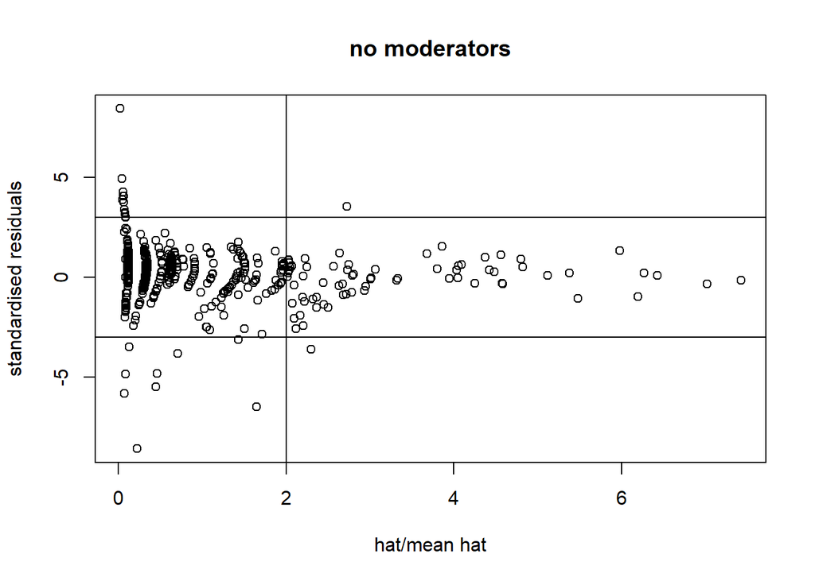

```r
rstn <- rstandard(ex.mv)
hat <- hatvalues(ex.mv) / mean(hatvalues(ex.mv))
plot(hat, rstn$resid,
     xlab = "hat/mean hat",
     ylab = "standardised residuals",
     main = "no moderators")
abline(h = -3)
abline(h = 3)
abline(v = 2)
```

Habeck outliers

```r
filter(ex, obs_ID == 457)[ , c("paper", "obs_ID")]
```

```
##          paper obs_ID
## 1 Hoelzle_2010    457
```

```r
filter(ex, obs_ID == 601)[ , c("paper", "obs_ID")]
```

```
##          paper obs_ID
## 1 LeJeune_2006    601
```

## Viechtbauer method

### Estimate

```r
rstd <- rstudent(ex.mv, reestimate = FALSE, progbar = TRUE) # ~ 4 min (ThinkPad)
```

```r
x <- subset(rstd, rstd$resid > 1.96)
y <- subset(rstd, rstd$resid < -1.96)
length(x[["resid"]]) + length(y[["resid"]])
```

```
## [1] 40
```

```r
ex.mv$k / 10
```

```
## [1] 48.8
```

```r
dfb <- dfbetas.rma.mv(ex.mv, reestimate = FALSE, progbar = TRUE) # ~ 4 min (ThinkPad)
```

```r
summary(dfb) # examine minimums and maximums
```

```
##     intrcpt
##  Min.   :-0.1773342
##  1st Qu.:-0.0043968
##  Median :-0.0003576
##  Mean   :-0.0004753
##  3rd Qu.: 0.0045689
##  Max.   : 0.1623610
```

- Comparison with previous dataset that included density: outliers were observations 457 and 601.

# Biome

```r
ex.mv.bio <- rma.mv(yi = yi,
                    V = vi,
                    random = ~ 1 | exp_ID / obs_ID,
                    data = ex,
                    mods = ~ factor(biome) - 1)
```

- Run multilevel model with `biome` as a moderator.

## Habeck method

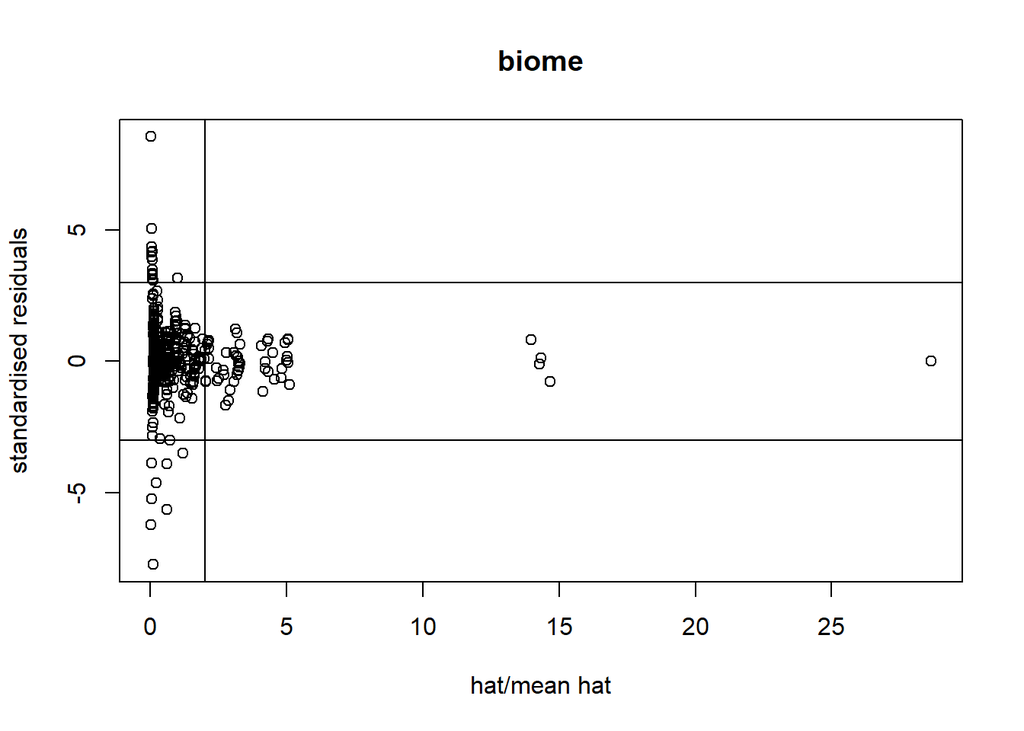

```r
rstn <- rstandard(ex.mv.bio)
hat <- hatvalues(ex.mv.bio) / mean(hatvalues(ex.mv.bio))
plot(hat, rstn$resid,
     xlab = "hat/mean hat",
     ylab = "standardised residuals",
     main = "biome")
abline(h = -3)
abline(h = 3)
abline(v = 2)
```

- The above chunk of code came directly from the Habeck 2015 paper.
- Habeck outliers are points in the top right and bottom right sections.

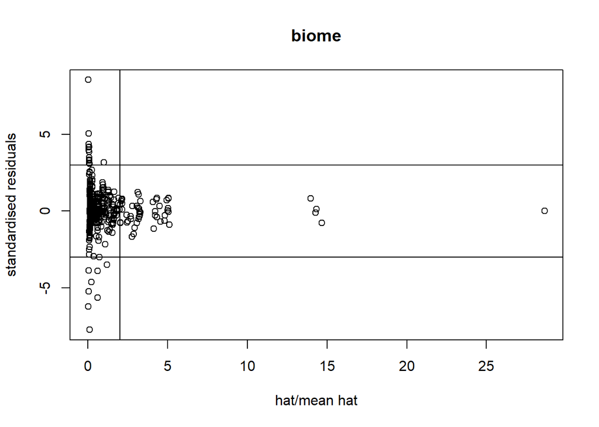

```r
plot(hat, rstn$resid,
     xlab = "hat/mean hat",
     ylab = "standardised residuals",
     main = "biome")
abline(h = -3)
abline(h = 3)
abline(v = 2)
```

- Points can be identified by `obs_ID`. Labels are assigned to each point using `text()` (see Introduction), which makes the plot very messy, so that is omitted here.

## Viechtbauer method

Estimate

```r
rstd.bio <- rstudent(ex.mv.bio, reestimate = FALSE, progbar = TRUE)
```

```r
x <- subset(rstd.bio, rstd.bio$resid > 1.96)
y <- subset(rstd.bio, rstd.bio$resid < -1.96)
length(x[["resid"]]) + length(y[["resid"]])
```

```
## [1] 37
```

```r
ex.mv.bio$k / 10
```

```
## [1] 48.7
```

- Subset points with studentized deleted residual >1.96 and <-1.96.
- Then ensure number of points < *k*/10 (it is; 37 < 48.7).

```r
dfb.bio <- dfbetas.rma.mv(ex.mv.bio, reestimate = FALSE, progbar = TRUE)
```

```r
summary(dfb.bio)
```

```
##  factor.biome.coastal.grassland factor.biome.coastal.sage.scrub
##  Min.   :-0.2879973             Min.   :-0.1519052
##  1st Qu.: 0.0000000             1st Qu.: 0.0000000
##  Median : 0.0000000             Median : 0.0000000
##  Mean   :-0.0002466             Mean   : 0.0000012
##  3rd Qu.: 0.0000000             3rd Qu.: 0.0000000
##  Max.   : 0.2453804             Max.   : 0.1524957
##  NA's   :2                      NA's   :2
##  factor.biome.coastal.sandplain.grassland factor.biome.cold.desert
##  Min.   :-0.0982425                       Min.   :-0.35324
##  1st Qu.: 0.0000000                       1st Qu.: 0.00000
##  Median : 0.0000000                       Median : 0.00000
##  Mean   :-0.0000045                       Mean   : 0.00004
##  3rd Qu.: 0.0000000                       3rd Qu.: 0.00000
##  Max.   : 0.1225558                       Max.   : 0.32411
##  NA's   :2                                NA's   :2
##  factor.biome.creosote.scrub factor.biome.fescue.prairie factor.biome.fynbos
##  Min.   :-0.4444354          Min.   :-0.2932575          Min.   :-1.1093556
##  1st Qu.: 0.0000000          1st Qu.: 0.0000000          1st Qu.: 0.0000000
##  Median : 0.0000000          Median : 0.0000000          Median : 0.0000000
##  Mean   : 0.0002393          Mean   : 0.0000082          Mean   :-0.0001085
##  3rd Qu.: 0.0000000          3rd Qu.: 0.0000000          3rd Qu.: 0.0000000
##  Max.   : 0.4638074          Max.   : 0.3303948          Max.   : 1.0567093
##  NA's   :2                   NA's   :2                   NA's   :2
##  factor.biome.grassy.woodland factor.biome.mixed.grass.prairie
##  Min.   :-0.443516            Min.   :-0.5578507
##  1st Qu.: 0.000000            1st Qu.: 0.0000000
##  Median : 0.000000            Median : 0.0000000
##  Mean   :-0.001323            Mean   :-0.0004872
##  3rd Qu.: 0.000000            3rd Qu.: 0.0000000
##  Max.   : 0.274472            Max.   : 0.3569531
##  NA's   :2                    NA's   :2
##  factor.biome.Puget.lowland.prairie factor.biome.sagebrush.steppe
##  Min.   :-0.1281661                 Min.   :-0.2372650
##  1st Qu.: 0.0000000                 1st Qu.: 0.0000000
##  Median : 0.0000000                 Median : 0.0000000
##  Mean   : 0.0000308                 Mean   : 0.0004305
##  3rd Qu.: 0.0000000                 3rd Qu.: 0.0000000
##  Max.   : 0.2043688                 Max.   : 0.4474768
##  NA's   :2                          NA's   :2
```

[output cut: 9 more lines]

```
##  Min.   :-0.135133              Min.   :-0.533887
##  1st Qu.: 0.000000              1st Qu.: 0.000000
##  Median : 0.000000              Median : 0.000000
##  Mean   : 0.000131              Mean   :-0.001648
##  3rd Qu.: 0.000000              3rd Qu.: 0.000000
##  Max.   : 0.205448              Max.   : 0.024968
##  NA's   :2                      NA's   :2
##  factor.biome.upland.prairie factor.biome.wetland.prairie
##  Min.   :-0.214834           Min.   :-0.2385650
##  1st Qu.: 0.000000           1st Qu.: 0.0000000
##  Median : 0.000000           Median : 0.0000000
##  Mean   : 0.000024           Mean   : 0.0000055
##  3rd Qu.: 0.000000           3rd Qu.: 0.0000000
##  Max.   : 0.280852           Max.   : 0.2841632
##  NA's   :2                   NA's   :2
```

- Check the minimums and maximums of each moderator level and identify which level has a minimum < -1 or a maximum > 1.
- In this case, `fynbos` has a max > 1 and min < -1.

```r
subset(dfb.bio, dfb.bio$factor.biome.fynbos > 1) # 339
```

```
##     factor.biome.coastal.grassland factor.biome.coastal.sage.scrub
## 339                  -6.693561e-16                               0
##     factor.biome.coastal.sandplain.grassland factor.biome.cold.desert
## 339                            -1.053347e-16                        0
##     factor.biome.creosote.scrub factor.biome.fescue.prairie factor.biome.fynbos
## 339                           0                           0            1.056709
##     factor.biome.grassy.woodland factor.biome.mixed.grass.prairie
## 339                 3.479121e-15                                0
##     factor.biome.Puget.lowland.prairie factor.biome.sagebrush.steppe
## 339                      -5.853701e-17                             0
##     factor.biome.sedge.meadow factor.biome.shadscale.bunchgrass
## 339                         0                                 0
##     factor.biome.shortgrass.steppe factor.biome.tallgrass.prairie
## 339                              0                              0
##     factor.biome.upland.prairie factor.biome.wetland.prairie
## 339               -1.564973e-15                            0
```

- Use `subset()` to identify rows of `ex` with max > 1.

```r
x$slab # none
```

```
##  [1]  26  30  31  33  34  35  36  37  38  95 103 108 113 114 115 116 258 379 383
## [20] 384 392
```

- Check if points are also outliers with residuals > 1.96. See that 339 is not on the list.

```r
subset(dfb.bio, dfb.bio$factor.biome.fynbos < -1) # 338
```

```
##     factor.biome.coastal.grassland factor.biome.coastal.sage.scrub
## 338                  -6.693561e-16                               0
##     factor.biome.coastal.sandplain.grassland factor.biome.cold.desert
## 338                            -1.053347e-16                        0
##     factor.biome.creosote.scrub factor.biome.fescue.prairie factor.biome.fynbos
## 338                           0                           0           -1.109356
##     factor.biome.grassy.woodland factor.biome.mixed.grass.prairie
## 338                 3.479121e-15                                0
##     factor.biome.Puget.lowland.prairie factor.biome.sagebrush.steppe
## 338                      -5.853701e-17                             0
##     factor.biome.sedge.meadow factor.biome.shadscale.bunchgrass
## 338                         0                                 0
##     factor.biome.shortgrass.steppe factor.biome.tallgrass.prairie
## 338                              0                              0
##     factor.biome.upland.prairie factor.biome.wetland.prairie
## 338               -1.564973e-15                            0
```

```r
y$slab # none
```

```
##  [1] 152 153 161 162 163 164 245 307 308 309 337 356 364 416 419 420
```

```r
ex[c(339, 338), c("paper", "obs_ID", "biome")]
```

```
##           paper obs_ID  biome
## 339 Holmes_2008    468 fynbos
## 338 Holmes_2008    467 fynbos
```

- Observations 468 and 467 are influential, but not outliers.
- Comparison with previous dataset that included density: outliers were observations 1610 and 457.
  - Observation 1610 was density data from Rashid 2010 (Kashmir Himalaya), and is not included in this new no-density `ex`.

# Region

```r
ex.mv.reg <- rma.mv(yi = yi,
                    V = vi,
                    random = ~ 1 | exp_ID / obs_ID,
                    data = ex,
                    mods = ~ factor(region) - 1)
```

## Habeck method

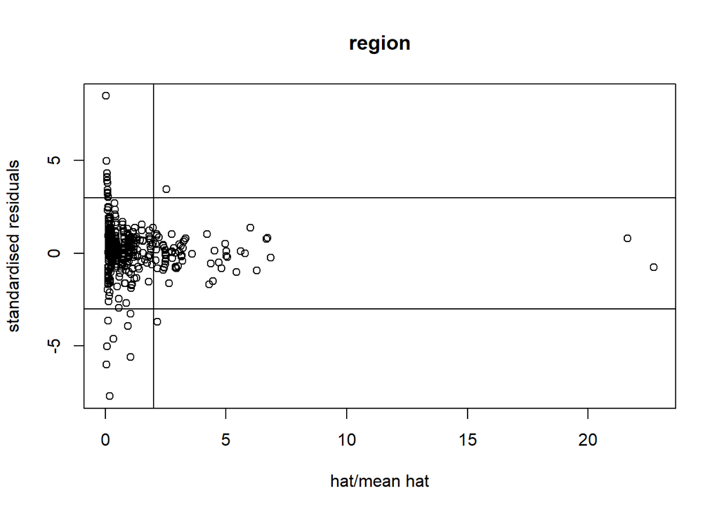

```r
rstn <- rstandard(ex.mv.reg)
hat <- hatvalues(ex.mv.reg) / mean(hatvalues(ex.mv.reg))
plot(hat, rstn$resid,
     xlab = "hat/mean hat",
     ylab = "standardised residuals",
     main = "region")
abline(h = -3)
abline(h = 3)
abline(v = 2)
```

Habeck outliers

```r
filter(ex, obs_ID == 601)[ , c("paper", "obs_ID", "region")]
```

```
##          paper obs_ID               region
## 1 LeJeune_2006    601 Rocky Mountains, USA
```

```r
filter(ex, obs_ID == 457)[ , c("paper", "obs_ID", "region")]
```

```
##          paper obs_ID               region
## 1 Hoelzle_2010    457 Rocky Mountains, USA
```

## Viechtbauer method

Estimate

```r
rstd.reg <- rstudent(ex.mv.reg, reestimate = FALSE, progbar = TRUE)
```

```r
x <- subset(rstd.reg, rstd.reg$resid > 1.96)
y <- subset(rstd.reg, rstd.reg$resid < -1.96)
length(x[["resid"]]) + length(y[["resid"]])
```

```
## [1] 39
```

```r
ex.mv.reg$k / 10
```

```
## [1] 48.8
```

```r
dfb.reg <- dfbetas.rma.mv(ex.mv.reg, reestimate = FALSE, progbar = TRUE)
```

```r
summary(dfb.reg)
```

```
##  factor.region.central.Canada factor.region.coastal.CA..USA
##  Min.   :-0.2530897           Min.   :-0.2675850
##  1st Qu.: 0.0000000           1st Qu.: 0.0000000
##  Median : 0.0000000           Median : 0.0000000
##  Mean   :-0.0003629           Mean   :-0.0001901
##  3rd Qu.: 0.0000000           3rd Qu.: 0.0000000
##  Max.   : 0.2017603           Max.   : 0.2313659
##  factor.region.Great.Basin..USA factor.region.Great.Plains..USA
##  Min.   :-0.2233489             Min.   :-0.2500241
##  1st Qu.: 0.0000000             1st Qu.: 0.0000000
##  Median : 0.0000000             Median : 0.0000000
##  Mean   :-0.0003576             Mean   :-0.0003066
##  3rd Qu.: 0.0000000             3rd Qu.: 0.0000000
##  Max.   : 0.1254341             Max.   : 0.2222419
##  factor.region.Midwest..USA factor.region.northeast.USA
##  Min.   :-0.4694456         Min.   :-9.157e-02
##  1st Qu.: 0.0000000         1st Qu.: 0.000e+00
##  Median : 0.0000000         Median : 0.000e+00
##  Mean   :-0.0009662         Mean   :-4.190e-06
##  3rd Qu.: 0.0000000         3rd Qu.: 0.000e+00
##  Max.   : 0.6579737         Max.   : 1.143e-01
##  factor.region.Pacific.Northwest..USA factor.region.Rocky.Mountains..USA
##  Min.   :-0.1572211                   Min.   :-0.6058116
##  1st Qu.: 0.0000000                   1st Qu.: 0.0000000
##  Median : 0.0000000                   Median : 0.0000000
##  Mean   : 0.0002629                   Mean   : 0.0004977
##  3rd Qu.: 0.0000000                   3rd Qu.: 0.0000000
##  Max.   : 0.1684303                   Max.   : 0.5938044
##  factor.region.South.Africa factor.region.southeast.Australia
##  Min.   :-1.0674635         Min.   :-0.448702
##  1st Qu.: 0.0000000         1st Qu.: 0.000000
##  Median : 0.0000000         Median : 0.000000
##  Mean   :-0.0001036         Mean   :-0.001332
##  3rd Qu.: 0.0000000         3rd Qu.: 0.000000
##  Max.   : 1.0169287         Max.   : 0.265178
##  factor.region.southwest.USA
##  Min.   :-0.4194400
##  1st Qu.: 0.0000000
##  Median : 0.0000000
##  Mean   : 0.0002322
##  3rd Qu.: 0.0000000
##  Max.   : 0.4425971
```

```r
subset(dfb.reg, dfb.reg$factor.region.South.Africa > 1) # 339
```

```
##     factor.region.central.Canada factor.region.coastal.CA..USA
## 339                            0                             0
##     factor.region.Great.Basin..USA factor.region.Great.Plains..USA
## 339                              0                               0
##     factor.region.Midwest..USA factor.region.northeast.USA
## 339                          0               -1.963428e-16
##     factor.region.Pacific.Northwest..USA factor.region.Rocky.Mountains..USA
## 339                        -5.102076e-16                                  0
##     factor.region.South.Africa factor.region.southeast.Australia
## 339                   1.016929                                 0
##     factor.region.southwest.USA
## 339                           0
```

```r
x$slab # none
```

```
##  [1]  26  30  31  34  35  36  37  38  95 103 108 113 114 115 116 199 258 378 379
## [20] 383 384 392
```

```r
subset(dfb.reg, dfb.reg$factor.region.South.Africa < -1) # 338
```

```
##     factor.region.central.Canada factor.region.coastal.CA..USA
## 338                            0                             0
##     factor.region.Great.Basin..USA factor.region.Great.Plains..USA
## 338                              0                               0
##     factor.region.Midwest..USA factor.region.northeast.USA
## 338                          0               -1.963428e-16
##     factor.region.Pacific.Northwest..USA factor.region.Rocky.Mountains..USA
## 338                        -5.102076e-16                                  0
##     factor.region.South.Africa factor.region.southeast.Australia
## 338                  -1.067464                                 0
##     factor.region.southwest.USA
## 338                           0
```

```r
y$slab # none
```

```
##  [1]  25 152 153 161 162 163 164 245 307 308 309 337 356 364 416 419 420
```

```r
ex[c(339, 338), c("paper", "obs_ID", "region")]
```

```
##           paper obs_ID       region
## 339 Holmes_2008    468 South Africa
## 338 Holmes_2008    467 South Africa
```

- Observations 601 and 457 are Habeck outliers.
- Observations 468 and 467 are influential, but not outliers.
- Comparison with previous dataset that included density: outliers were Observations 1610 and 457.
  - Observation 1610 was density data from Rashid 2010 (Himalaya), and is not included in this new no-density `ex`.

# Soil suborder

```r
ex.mv.soil <- rma.mv(yi = yi,
                    V = vi,
                    random = ~ 1 | exp_ID / obs_ID,
                    data = ex,
                    mods = ~ factor(soil_suborder) - 1)
```

## Habeck method

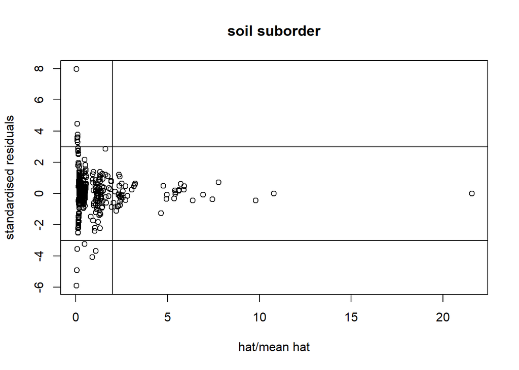

```r
rstn <- rstandard(ex.mv.soil)
hat <- hatvalues(ex.mv.soil) / mean(hatvalues(ex.mv.soil))
plot(hat, rstn$resid,
     xlab = "hat/mean hat",
     ylab = "standardised residuals",
     main = "soil suborder")
abline(h = -3)
abline(h = 3)
abline(v = 2)
```

## Viechtbauer method

Estimate

```r
rstd.soil <- rstudent(ex.mv.soil, reestimate = FALSE, progbar = TRUE)
```

```r
x <- subset(rstd.soil, rstd.soil$resid > 1.96)
y <- subset(rstd.soil, rstd.soil$resid < -1.96)
length(x[["resid"]]) + length(y[["resid"]])
```

```
## [1] 37
```

```r
ex.mv.soil$k / 10
```

```
## [1] 41
```

```r
dfb.soil <- dfbetas.rma.mv(be.mv.soil, reestimate = FALSE, progbar = TRUE)
```

```r
summary(dfb.soil)
```

```
##  factor.soil_suborder.Aqualfs factor.soil_suborder.Aquolls
##  Min.   :-0.2450425           Min.   :-0.3956205
##  1st Qu.: 0.0000000           1st Qu.: 0.0000000
##  Median : 0.0000000           Median : 0.0000000
##  Mean   : 0.0000068           Mean   : 0.0001191
##  3rd Qu.: 0.0000000           3rd Qu.: 0.0000000
##  Max.   : 0.2922673           Max.   : 0.8201153
##  NA's   :1                    NA's   :1
##  factor.soil_suborder.Argids factor.soil_suborder.Blacktown
##  Min.   :-0.6458088          Min.   :-0.3319624
##  1st Qu.: 0.0000000          1st Qu.: 0.0000000
##  Median : 0.0000000          Median : 0.0000000
##  Mean   : 0.0002554          Mean   :-0.0005411
##  3rd Qu.: 0.0000000          3rd Qu.: 0.0000000
##  Max.   : 0.3364395          Max.   : 0.1092172
##  NA's   :1                   NA's   :1
##  factor.soil_suborder.Calcids factor.soil_suborder.Cambids
##  Min.   :-0.3144564           Min.   :-0.2519069
##  1st Qu.: 0.0000000           1st Qu.: 0.0000000
##  Median : 0.0000000           Median : 0.0000000
##  Mean   : 0.0001155           Mean   : 0.0009176
##  3rd Qu.: 0.0000000           3rd Qu.: 0.0000000
##  Max.   : 0.2005844           Max.   : 0.6415288
##  NA's   :1                    NA's   :1
##  factor.soil_suborder.Chernozems factor.soil_suborder.Humults
##  Min.   :-0.2737700              Min.   :-0.311985
##  1st Qu.: 0.0000000              1st Qu.: 0.000000
##  Median : 0.0000000              Median : 0.000000
##  Mean   :-0.0004948              Mean   : 0.000129
##  3rd Qu.: 0.0000000              3rd Qu.: 0.000000
##  Max.   : 0.2094604              Max.   : 0.243000
##  NA's   :1                       NA's   :1
##  factor.soil_suborder.Orthents factor.soil_suborder.Psamments..Udepts
##  Min.   :-0.6889497            Min.   :-0.1009565
##  1st Qu.: 0.0000000            1st Qu.: 0.0000000
##  Median : 0.0000000            Median : 0.0000000
##  Mean   :-0.0008534            Mean   :-0.0000056
##  3rd Qu.: 0.0000000            3rd Qu.: 0.0000000
##  Max.   : 0.2617109            Max.   : 0.1257088
##  NA's   :1                     NA's   :1
```

[output cut: 25 more lines]

```
##  Min.   :-0.1902053           Min.   :-0.1568617
##  1st Qu.: 0.0000000           1st Qu.: 0.0000000
##  Median : 0.0000000           Median : 0.0000000
##  Mean   :-0.0000604           Mean   : 0.0000547
##  3rd Qu.: 0.0000000           3rd Qu.: 0.0000000
##  Max.   : 0.2571602           Max.   : 0.1182274
##  NA's   :1                    NA's   :1
##  factor.soil_suborder.Xerolls
##  Min.   :-0.2529028
##  1st Qu.: 0.0000000
##  Median : 0.0000000
##  Mean   :-0.0002069
##  3rd Qu.: 0.0000000
##  Max.   : 0.3296613
##  NA's   :1
```

- Comparison with previous dataset that included density: no differences.

# duration_first (continuous)

```r
ex.mv.df <- rma.mv(yi = yi,
                     V = vi,
                     random = ~ 1 | exp_ID / obs_ID,
                     data = ex,
                     mods = ~ duration_first - 1)
```

## Habeck method

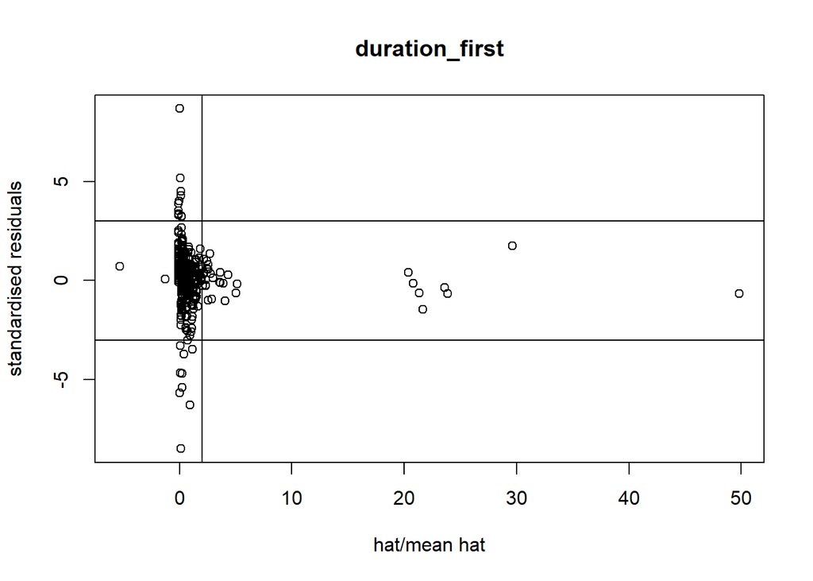

```r
rstn <- rstandard(ex.mv.df)
hat <- hatvalues(ex.mv.df) / mean(hatvalues(ex.mv.df))
plot(hat, rstn$resid,
     xlab = "hat/mean hat",
     ylab = "standardised residuals",
     main = "duration_first")
abline(h = -3)
abline(h = 3)
abline(v = 2)
```

## Viechtbauer method

Estimate

```r
rstd.df <- rstudent(ex.mv.df, reestimate = FALSE, progbar = TRUE)
```

```r
x <- subset(rstd.df, rstd.df$resid > 1.96)
y <- subset(rstd.df, rstd.df$resid < -1.96)
length(x[["resid"]]) + length(y[["resid"]])
```

```
## [1] 41
```

```r
ex.mv.df$k / 10
```

```
## [1] 48.8
```

```r
dfb.df <- dfbetas.rma.mv(ex.mv.df, reestimate = FALSE, progbar = TRUE)
```

```r
summary(dfb.df)
```

```
##     intrcpt           duration_first
##  Min.   :-0.1979842   Min.   :-0.5528331
##  1st Qu.:-0.0082100   1st Qu.:-0.0031122
##  Median :-0.0008638   Median : 0.0005156
##  Mean   :-0.0004870   Mean   :-0.0001344
##  3rd Qu.: 0.0064857   3rd Qu.: 0.0046422
##  Max.   : 0.1976783   Max.   : 0.5536887
```

- Comparison with previous dataset that included density: no differences.

# duration_first (categorical)

```r
ex.mv.dfc <- rma.mv(yi = yi,
                    V = vi,
                    random = ~ 1 | exp_ID / obs_ID,
                    data = ex,
                    mods = ~ factor(dfc) - 1)
```

## Habeck method

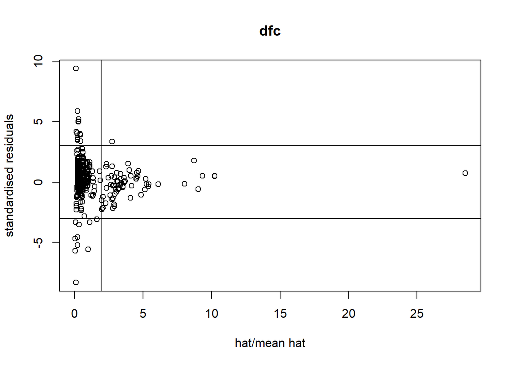

```r
rstn <- rstandard(ex.mv.dfc)
hat <- hatvalues(ex.mv.dfc) / mean(hatvalues(ex.mv.dfc))
plot(hat, rstn$resid,
     xlab = "hat/mean hat",
     ylab = "standardised residuals",
     main = "dfc")
abline(h = -3)
abline(h = 3)
abline(v = 2)
```

```r
filter(ex, obs_ID == 457)[ , c("paper", "obs_ID", "dfc")]
```

```
##          paper obs_ID  dfc
## 1 Hoelzle_2010    457 >200
```

## Viechtbauer method

Estimate

```r
rstd.dfc <- rstudent(ex.mv.dfc, reestimate = FALSE, progbar = TRUE)
```

```r
x <- subset(rstd.dfc, rstd.dfc$resid > 1.96)
y <- subset(rstd.dfc, rstd.dfc$resid < -1.96)
length(x[["resid"]]) + length(y[["resid"]])
```

```
## [1] 53
```

```r
ex.mv.dfc$k / 10
```

```
## [1] 48.8
```

```r
dfb.dfc <- dfbetas.rma.mv(ex.mv.dfc, reestimate = FALSE, progbar = TRUE)
```

```r
summary(dfb.dfc)
```

```
##   factor.dfc.3       factor.dfc.5.6      factor.dfc.7.12
##  Min.   :-0.341464   Min.   :-0.234300   Min.   :-0.218856
##  1st Qu.: 0.000000   1st Qu.: 0.000000   1st Qu.: 0.000000
##  Median : 0.000000   Median : 0.000000   Median : 0.000000
##  Mean   :-0.001184   Mean   : 0.001539   Mean   :-0.001359
##  3rd Qu.: 0.000000   3rd Qu.: 0.000000   3rd Qu.: 0.000000
##  Max.   : 0.286322   Max.   : 0.384682   Max.   : 0.100992
##  factor.dfc.12.18     factor.dfc.19.24     factor.dfc.25.36
##  Min.   :-0.3121195   Min.   :-0.3657700   Min.   :-0.278112
##  1st Qu.: 0.0000000   1st Qu.: 0.0000000   1st Qu.: 0.000000
##  Median : 0.0000000   Median : 0.0000000   Median : 0.000000
##  Mean   :-0.0007768   Mean   :-0.0006717   Mean   : 0.001506
##  3rd Qu.: 0.0000000   3rd Qu.: 0.0000000   3rd Qu.: 0.000000
##  Max.   : 0.3414529   Max.   : 0.2629702   Max.   : 0.849569
##  factor.dfc.37.50    factor.dfc.100.200  factor.dfc..200
##  Min.   :-0.520347   Min.   :-0.159706   Min.   :-0.214192
##  1st Qu.: 0.000000   1st Qu.: 0.000000   1st Qu.: 0.000000
##  Median : 0.000000   Median : 0.000000   Median : 0.000000
##  Mean   :-0.001165   Mean   : 0.001744   Mean   : 0.001749
##  3rd Qu.: 0.000000   3rd Qu.: 0.000000   3rd Qu.: 0.000000
##  Max.   : 0.120781   Max.   : 0.624309   Max.   : 0.670714
```

- Observation 457 is a Habeck outlier.
- Number of outliers > *k*/10, where Observations 59, 47, 56, 55, and 51 had the largest studentized deleted residuals.
  - This does not warrant removal as an outlier; it demonstrates that `dfc` has an unusual amount of outliers, but they are not influential.
- Comparison with previous dataset that included density: Obs 457 is now an outlier, and there are outliers > *k*/10.

# duration_last (continuous)

```r
ex.mv.dl <- rma.mv(yi = yi,
                   V = vi,
                   random = ~ 1 | exp_ID / obs_ID,
                   data = ex,
                   mods = ~ duration_last)
```

## Habeck method

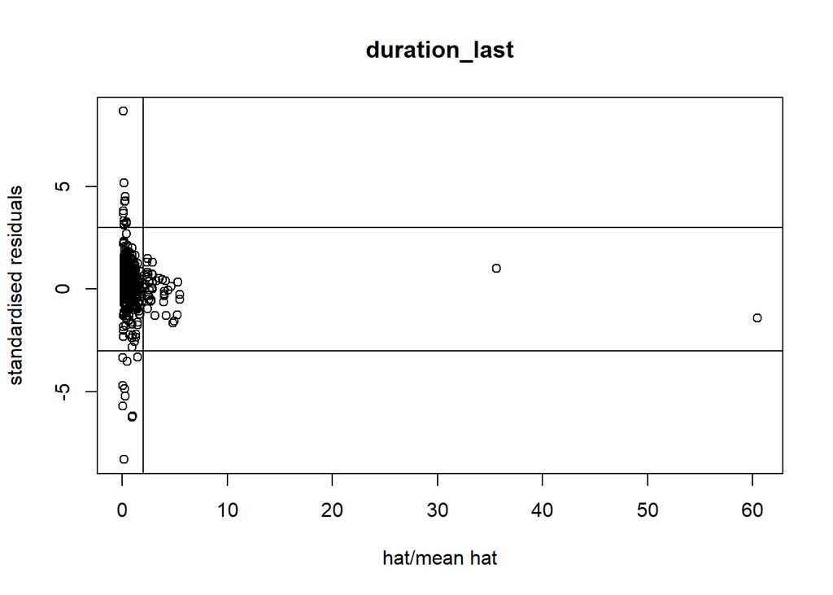

```r
rstn <- rstandard(ex.mv.dl)
hat <- hatvalues(ex.mv.dl) / mean(hatvalues(ex.mv.dl))
plot(hat, rstn$resid,
     xlab = "hat/mean hat",
     ylab = "standardised residuals",
     main = "duration_last")
abline(h = -3)
abline(h = 3)
abline(v = 2)
```

## Viechtbauer method

Estimate

```r
rstd.dl <- rstudent(ex.mv.dl, reestimate = FALSE, progbar = TRUE)
```

```r
x <- subset(rstd.dl, rstd.dl$resid > 1.96)
y <- subset(rstd.dl, rstd.dl$resid < -1.96)
length(x[["resid"]]) + length(y[["resid"]])
```

```
## [1] 40
```

```r
ex.mv.dl$k / 10
```

```
## [1] 48.8
```

```r
dfb.dl <- dfbetas.rma.mv(ex.mv.dl, reestimate = FALSE, progbar = TRUE)
```

```r
summary(dfb.dl)
```

```
##     intrcpt           duration_last
##  Min.   :-0.1959101   Min.   :-0.9628060
##  1st Qu.:-0.0096771   1st Qu.:-0.0072394
##  Median :-0.0003953   Median : 0.0001797
##  Mean   :-0.0013486   Mean   : 0.0007833
##  3rd Qu.: 0.0084821   3rd Qu.: 0.0094492
##  Max.   : 0.3510207   Max.   : 0.4651346
```

- Comparison with previous dataset that included density: Observation 459 is no longer an influential outlier (and still present in datset).

# duration_last (categorical)

```r
ex.mv.dlc <- rma.mv(yi = yi,
                    V = vi,
                    random = ~ 1 | exp_ID / obs_ID,
                    data = ex,
                    mods = ~ factor(dlc) - 1)
```

## Habeck method

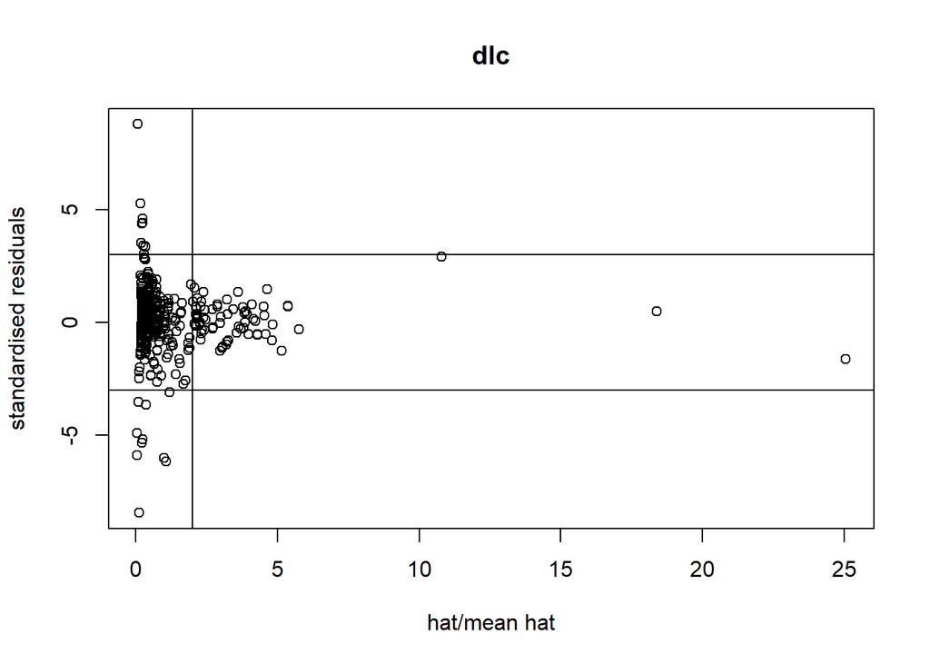

```r
rstn <- rstandard(ex.mv.dlc)
hat <- hatvalues(ex.mv.dlc) / mean(hatvalues(ex.mv.dlc))
plot(hat, rstn$resid,
     xlab = "hat/mean hat",
     ylab = "standardised residuals",
     main = "dlc")
abline(h = -3)
abline(h = 3)
abline(v = 2)
```

## Viechtbauer method

Estimate

```r
rstd.dlc <- rstudent(ex.mv.dlc, reestimate = FALSE, progbar = TRUE)
```

```r
x <- subset(rstd.dlc, rstd.dlc$resid > 1.96)
y <- subset(rstd.dlc, rstd.dlc$resid < -1.96)
length(x[["resid"]]) + length(y[["resid"]])
```

```
## [1] 42
```

```r
ex.mv.dlc$k / 10
```

```
## [1] 48.8
```

```r
dfb.dlc <- dfbetas.rma.mv(ex.mv.dlc, reestimate = FALSE, progbar = TRUE)
```

```r
summary(dfb.dlc)
```

```
##  factor.dlc.0.1.5      factor.dlc.2        factor.dlc.3.3.5
##  Min.   :-0.4183364   Min.   :-0.3180306   Min.   :-0.448440
##  1st Qu.:-0.0000112   1st Qu.:-0.0006129   1st Qu.:-0.002428
##  Median : 0.0000000   Median : 0.0000000   Median : 0.000000
##  Mean   : 0.0000987   Mean   :-0.0001723   Mean   :-0.000633
##  3rd Qu.: 0.0000112   3rd Qu.: 0.0005051   3rd Qu.: 0.002246
##  Max.   : 0.3753267   Max.   : 0.2296697   Max.   : 0.338402
##  factor.dlc.4.6       factor.dlc.7.12      factor.dlc.13.18
##  Min.   :-0.3065353   Min.   :-0.3537929   Min.   :-0.3726461
##  1st Qu.:-0.0002264   1st Qu.:-0.0013705   1st Qu.:-0.0024711
##  Median : 0.0000000   Median : 0.0000000   Median : 0.0000000
##  Mean   : 0.0007895   Mean   :-0.0004207   Mean   :-0.0004188
##  3rd Qu.: 0.0002176   3rd Qu.: 0.0011337   3rd Qu.: 0.0020384
##  Max.   : 0.3249283   Max.   : 0.4689804   Max.   : 0.2714036
##  factor.dlc.19.24     factor.dlc.36.49     factor.dlc..100
##  Min.   :-0.4340561   Min.   :-0.1240826   Min.   :-2.194974
##  1st Qu.: 0.0000000   1st Qu.: 0.0000000   1st Qu.: 0.000000
##  Median : 0.0000000   Median : 0.0000000   Median : 0.000000
##  Mean   :-0.0003866   Mean   :-0.0002578   Mean   :-0.003056
##  3rd Qu.: 0.0000000   3rd Qu.: 0.0000000   3rd Qu.: 0.000000
##  Max.   : 0.3256735   Max.   : 0.1258159   Max.   : 0.962734
```

```r
subset(dfb.dlc, dfb.dlc$factor.dlc..100 < -1) # 5
```

```
##   factor.dlc.0.1.5 factor.dlc.2 factor.dlc.3.3.5 factor.dlc.4.6 factor.dlc.7.12
## 5                0            0     2.328762e-15              0    8.727503e-16
##   factor.dlc.13.18 factor.dlc.19.24 factor.dlc.36.49 factor.dlc..100
## 5    -3.603807e-16                0    -2.513226e-16       -2.194974
```

```r
y$slab # none
```

```
##  [1]   5 152 153 161 162 163 164 245 307 308 309 337 356 364 396 416 417 419 420
## [20] 421 479 480
```

```r
ex[5, c("paper", "obs_ID", "dlc")]
```

```
##          paper obs_ID  dlc
## 5 Averett_2004     11 >100
```

- Observation 11 is influential, but not an outlier.
- Comparison with previous dataset that included density: Observations 457 and 459 are no longer influential outliers (and still present in datset).

# C type

```r
ex.mv.ctyp <- rma.mv(yi = yi,
                     V = vi,
                     random = ~ 1 | exp_ID / obs_ID,
                     data = ex,
                     mods = ~ factor(C_type) - 1)
```

## Habeck method

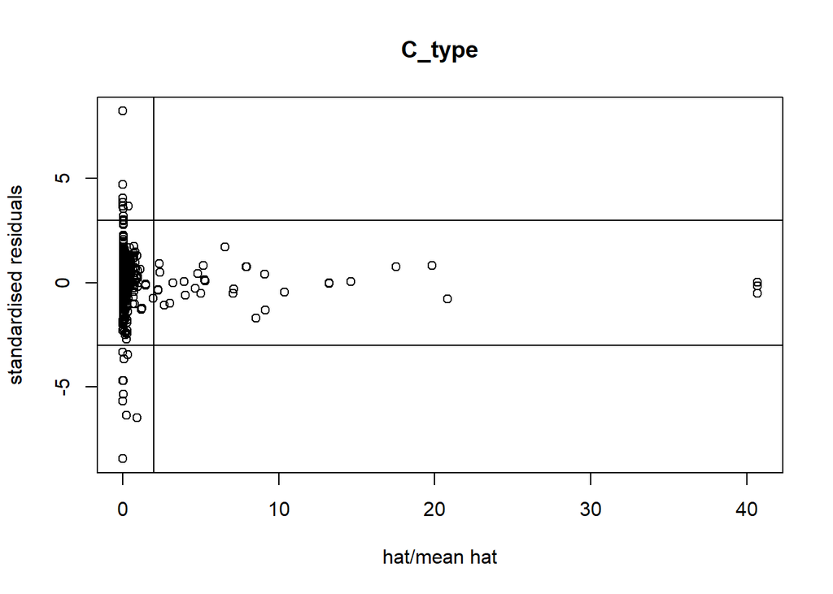

```r
rstn <- rstandard(ex.mv.ctyp)
hat <- hatvalues(ex.mv.ctyp) / mean(hatvalues(ex.mv.ctyp))
plot(hat, rstn$resid,
     xlab = "hat/mean hat",
     ylab = "standardised residuals",
     main = "C_type")
abline(h = -3)
abline(h = 3)
abline(v = 2)
```

## Viechtbauer method

Estimate

```r
rstd.ctyp <- rstudent(ex.mv.ctyp, reestimate = FALSE, progbar = TRUE)
```

```r
x <- subset(rstd.ctyp, rstd.ctyp$resid > 1.96)
y <- subset(rstd.ctyp, rstd.ctyp$resid < -1.96)
length(x[["resid"]]) + length(y[["resid"]])
```

```
## [1] 39
```

```r
ex.mv.ctyp$k / 10
```

```
## [1] 48.8
```

```r
dfb.ctyp <- dfbetas.rma.mv(ex.mv.ctyp, reestimate = FALSE, progbar = TRUE)
```

```r
summary(dfb.ctyp)
```

```
##  factor.C_type.dextrose factor.C_type.lignin factor.C_type.lignin.AND.sucrose
##  Min.   :-0.502658      Min.   :-0.257104    Min.   :-0.255934
##  1st Qu.: 0.000000      1st Qu.:-0.000405    1st Qu.:-0.000403
##  Median : 0.000000      Median :-0.000038    Median :-0.000038
##  Mean   : 0.000393      Mean   :-0.000221    Mean   :-0.000220
##  3rd Qu.: 0.000000      3rd Qu.: 0.000446    3rd Qu.: 0.000444
##  Max.   : 0.657702      Max.   : 0.233516    Max.   : 0.232454
##  NA's   :4              NA's   :4            NA's   :4
##  factor.C_type.mulch factor.C_type.sawdust factor.C_type.sawdust.AND.woodchip
##  Min.   :-0.233499   Min.   :-0.509833     Min.   :-0.057840
##  1st Qu.:-0.000137   1st Qu.:-0.000170     1st Qu.:-0.000018
##  Median :-0.000001   Median :-0.000013     Median :-0.000001
##  Mean   : 0.000761   Mean   :-0.002128     Mean   : 0.000608
##  3rd Qu.: 0.000105   3rd Qu.: 0.000187     3rd Qu.: 0.000022
##  Max.   : 0.306781   Max.   : 0.255264     Max.   : 0.254407
##  NA's   :4           NA's   :4             NA's   :4
##  factor.C_type.straw factor.C_type.sucrose factor.C_type.sucrose.AND.mulch
##  Min.   :-0.319324   Min.   :-0.257515     Min.   :-0.192065
##  1st Qu.:-0.000077   1st Qu.:-0.001613     1st Qu.:-0.000120
##  Median :-0.000001   Median :-0.000018     Median :-0.000001
##  Mean   :-0.000336   Mean   : 0.000876     Mean   : 0.000274
##  3rd Qu.: 0.000042   3rd Qu.: 0.000984     3rd Qu.: 0.000073
##  Max.   : 0.256704   Max.   : 0.225453     Max.   : 0.252344
##  NA's   :4           NA's   :4             NA's   :4
##  factor.C_type.sucrose.AND.sawdust factor.C_type.woodchip
##  Min.   :-0.337583                 Min.   :-0.609748
##  1st Qu.:-0.000818                 1st Qu.:-0.000061
##  Median :-0.000019                 Median :-0.000003
##  Mean   :-0.001104                 Mean   :-0.001116
##  3rd Qu.: 0.000453                 3rd Qu.: 0.000074
##  Max.   : 0.091158                 Max.   : 0.423239
##  NA's   :4                         NA's   :4
##  factor.C_type.woodchip.mulch
##  Min.   :-0.978641
##  1st Qu.: 0.000000
##  Median : 0.000000
##  Mean   :-0.000096
##  3rd Qu.: 0.000000
##  Max.   : 0.931982
##  NA's   :4
```

- Comparison with previous dataset that included density: no differences.

# C rate (continuous)

```r
ex.mv.crat <- rma.mv(yi = yi,
                     V = vi,
                     random = ~ 1 | exp_ID / obs_ID,
                     data = ex,
                     mods = ~ C_rate)
```

## Habeck method

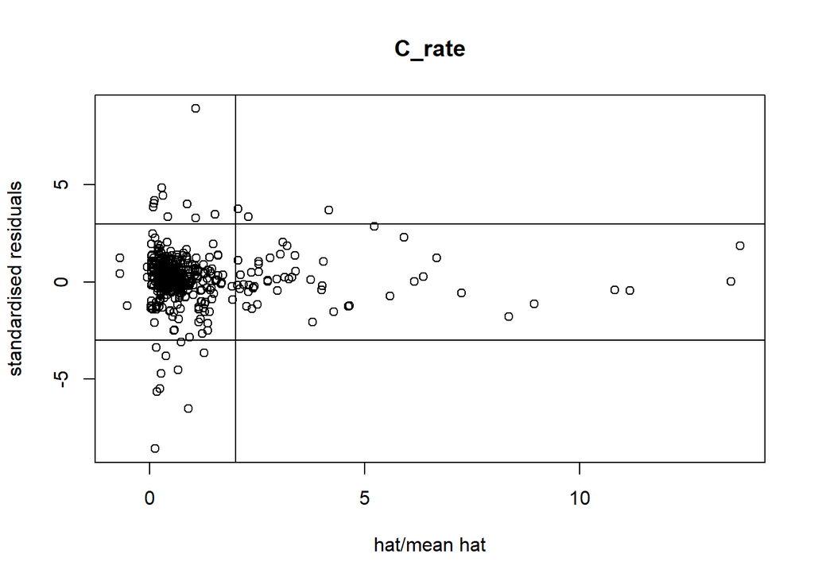

```r
rstn <- rstandard(ex.mv.crat)
hat <- hatvalues(ex.mv.crat) / mean(hatvalues(ex.mv.crat))
plot(hat, rstn$resid,
     xlab = "hat/mean hat",
     ylab = "standardised residuals",
     main = "C_rate")
abline(h = -3)
abline(h = 3)
abline(v = 2)
```

```r
filter(ex, obs_ID == 54)[ , c("paper", "obs_ID", "C_rate")]
```

```
##             paper obs_ID C_rate
## 1 Blumenthal_2003     54   1057
```

```r
filter(ex, obs_ID == 120)[ , c("paper", "obs_ID", "C_rate")]
```

```
##             paper obs_ID C_rate
## 1 Blumenthal_2003    120   1330
```

```r
filter(ex, obs_ID == 132)[ , c("paper", "obs_ID", "C_rate")]
```

```
##             paper obs_ID C_rate
## 1 Blumenthal_2003    132   1057
```

## Viechtbauer method

Estimate

```r
rstd.crat <- rstudent(ex.mv.crat, reestimate = FALSE, progbar = TRUE)
```

```r
x <- subset(rstd.crat, rstd.crat$resid > 1.96)
y <- subset(rstd.crat, rstd.crat$resid < -1.96)
length(x[["resid"]]) + length(y[["resid"]])
```

```
## [1] 40
```

```r
ex.mv.crat$k / 10
```

```
## [1] 46.6
```

```r
dfb.crat <- dfbetas.rma.mv(ex.mv.crat, reestimate = FALSE, progbar = TRUE)
```

```r
summary(dfb.crat)
```

```
##     intrcpt               C_rate
##  Min.   :-0.2341468   Min.   :-0.2878935
##  1st Qu.:-0.0086917   1st Qu.:-0.0077551
##  Median : 0.0002587   Median :-0.0002104
##  Mean   :-0.0004739   Mean   :-0.0000088
##  3rd Qu.: 0.0117834   3rd Qu.: 0.0036232
##  Max.   : 0.1843716   Max.   : 0.4156277
```

- Observations 54, 120, and 132 are Habeck outliers.
- Comparison with previous dataset that included density: Observations 54, 120, and 132 are now outliers.

# C rate (categorical)

```r
ex.mv.cratc <- rma.mv(yi = yi,
                      V = vi,
                      random = ~ 1 | exp_ID / obs_ID,
                      data = ex,
                      mods = ~ factor(cratc) - 1)
```

## Habeck method

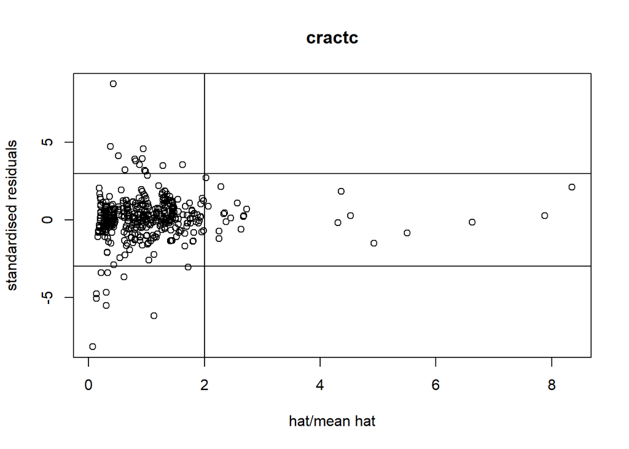

```r
rstn <- rstandard(ex.mv.cratc)
hat <- hatvalues(ex.mv.cratc) / mean(hatvalues(ex.mv.cratc))
plot(hat, rstn$resid,
     xlab = "hat/mean hat",
     ylab = "standardised residuals",
     main = "cractc")
abline(h = -3)
abline(h = 3)
abline(v = 2)
```

## Viechtbauer method

Estimate

```r
rstd.cratc <- rstudent(ex.mv.cratc, reestimate = FALSE, progbar = TRUE)
```

```r
x <- subset(rstd.cratc, rstd.cratc$resid > 1.96)
y <- subset(rstd.cratc, rstd.cratc$resid < -1.96)
length(x[["resid"]]) + length(y[["resid"]])
```

```
## [1] 40
```

```r
ex.mv.cratc$k / 10
```

```
## [1] 46.6
```

```r
dfb.cratc <- dfbetas.rma.mv(ex.mv.cratc, reestimate = FALSE, progbar = TRUE)
```

```r
summary(dfb.cratc)
```

```
##  factor.cratc.30.100  factor.cratc.133.160 factor.cratc.174.200
##  Min.   :-0.3721307   Min.   :-0.1322786   Min.   :-0.6117120
##  1st Qu.:-0.0072375   1st Qu.:-0.0076173   1st Qu.:-0.0034710
##  Median :-0.0002000   Median :-0.0002194   Median :-0.0001306
##  Mean   :-0.0002796   Mean   :-0.0008998   Mean   :-0.0001960
##  3rd Qu.: 0.0073868   3rd Qu.: 0.0060453   3rd Qu.: 0.0037072
##  Max.   : 0.2842613   Max.   : 0.3326290   Max.   : 0.2003276
##  factor.cratc.210.300 factor.cratc.330.400 factor.cratc.420.500
##  Min.   :-0.3778386   Min.   :-0.2973132   Min.   :-0.7012638
##  1st Qu.:-0.0062758   1st Qu.:-0.0067886   1st Qu.:-0.0012684
##  Median :-0.0001280   Median : 0.0002962   Median : 0.0000764
##  Mean   :-0.0006867   Mean   :-0.0006964   Mean   :-0.0000664
##  3rd Qu.: 0.0067063   3rd Qu.: 0.0070156   3rd Qu.: 0.0014695
##  Max.   : 0.2273960   Max.   : 0.3381338   Max.   : 0.8237371
##  factor.cratc.506.600 factor.cratc.620.700 factor.cratc.714.999
##  Min.   :-0.3849038   Min.   :-0.261570    Min.   :-0.2988401
##  1st Qu.:-0.0057647   1st Qu.:-0.003574    1st Qu.:-0.0064094
##  Median : 0.0002873   Median : 0.000064    Median : 0.0002157
##  Mean   :-0.0008356   Mean   : 0.001567    Mean   :-0.0004329
##  3rd Qu.: 0.0062696   3rd Qu.: 0.005105    3rd Qu.: 0.0067286
##  Max.   : 0.4490030   Max.   : 0.403184    Max.   : 0.2184506
##  factor.cratc.1000.1330 factor.cratc.1600.2000 factor.cratc.2110.3000
##  Min.   :-0.2679045     Min.   :-0.3840507     Min.   :-0.3273707
##  1st Qu.:-0.0076752     1st Qu.:-0.0068156     1st Qu.:-0.0075501
##  Median :-0.0002574     Median :-0.0000727     Median :-0.0001013
##  Mean   :-0.0005184     Mean   :-0.0006487     Mean   :-0.0005662
##  3rd Qu.: 0.0086186     3rd Qu.: 0.0066562     3rd Qu.: 0.0089787
##  Max.   : 0.3323779     Max.   : 0.5436405     Max.   : 0.4121877
##  factor.cratc.3346.5000 factor.cratc..5000
##  Min.   :-0.4830996     Min.   :-0.6766088
##  1st Qu.:-0.0058036     1st Qu.:-0.0020418
##  Median :-0.0001223     Median :-0.0000817
##  Mean   :-0.0006044     Mean   :-0.0002994
##  3rd Qu.: 0.0051888     3rd Qu.: 0.0020658
##  Max.   : 0.6490429     Max.   : 1.4425583
```

```r
subset(dfb.cratc, dfb.cratc$factor.cratc..5000 > 1) # 331
```

```
##     factor.cratc.30.100 factor.cratc.133.160 factor.cratc.174.200
## 331        -0.004246227         -0.003718594         -0.001553463
##     factor.cratc.210.300 factor.cratc.330.400 factor.cratc.420.500
## 331         -0.004058391         -0.004052558        -0.0008288462
##     factor.cratc.506.600 factor.cratc.620.700 factor.cratc.714.999
## 331         -0.003667226         -0.002868436         -0.003700242
##     factor.cratc.1000.1330 factor.cratc.1600.2000 factor.cratc.2110.3000
## 331           -0.004928858            -0.01322432           -0.005104714
##     factor.cratc.3346.5000 factor.cratc..5000
## 331            -0.01508228           1.442558
```

```r
x$slab # 331
```

```
##  [1]  26  30  31  33  34  35  36  37  38  90  95 103 108 113 114 115 116 199 242
## [20] 258 331 383
```

```r
ex[331, c("paper", "obs_ID", "cratc")]
```

```
##         paper obs_ID cratc
## 331 Gray_2013    437 >5000
```

- Observation 437 is an influential outlier.
- Comparison with previous dataset that included density: this is a new moderator.

# C applications (continuous)

```r
ex.mv.cap <- rma.mv(yi = yi,
                     V = vi,
                     random = ~ 1 | exp_ID / obs_ID,
                     data = ex,
                     mods = ~ C_app)
```

## Habeck method

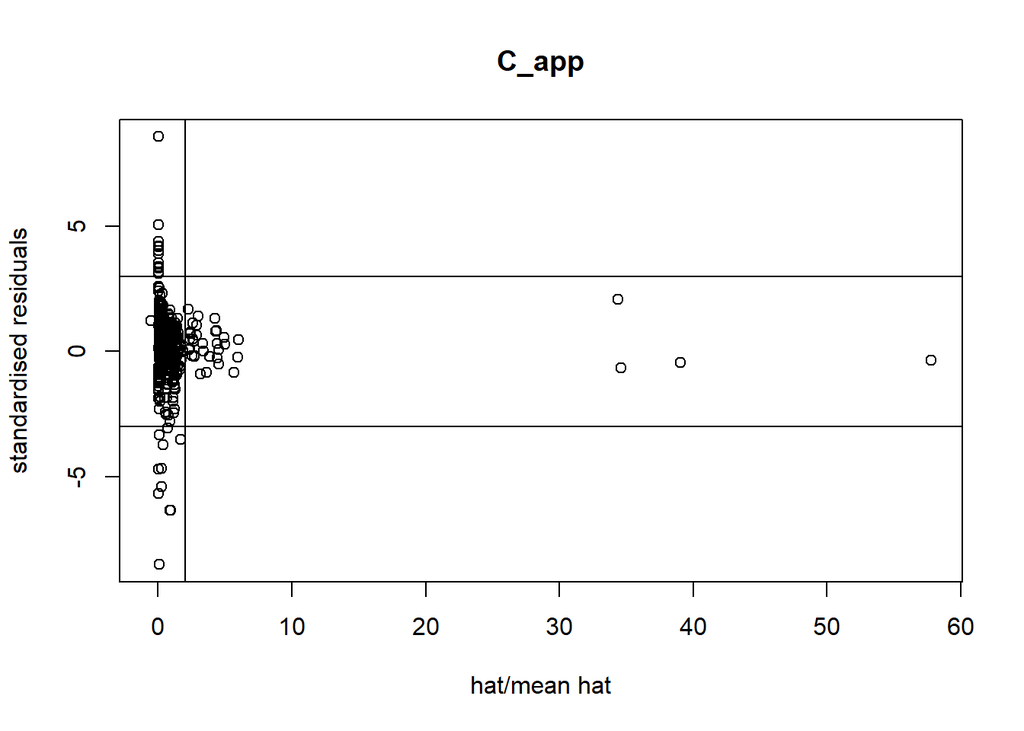

```r
rstn <- rstandard(ex.mv.cap)
hat <- hatvalues(ex.mv.cap) / mean(hatvalues(ex.mv.cap))
plot(hat, rstn$resid,
     xlab = "hat/mean hat",
     ylab = "standardised residuals",
     main = "C_app")
abline(h = -3)
abline(h = 3)
abline(v = 2)
```

## Viechtbauer method Estimate

```r
rstd.cap <- rstudent(ex.mv.cap, reestimate = FALSE, progbar = TRUE)
```

```r
x <- subset(rstd.cap, rstd.cap$resid > 1.96)
y <- subset(rstd.cap, rstd.cap$resid < -1.96)
length(x[["resid"]]) + length(y[["resid"]])
```

```
## [1] 40
```

```r
ex.mv.cap$k / 10
```

```
## [1] 48.8
```

```r
dfb.cap <- dfbetas.rma.mv(ex.mv.cap, reestimate = FALSE, progbar = TRUE)
```

```r
summary(dfb.cap)
```

```
##     intrcpt               C_app
##  Min.   :-0.3115720   Min.   :-0.4914108
##  1st Qu.:-0.0043151   1st Qu.:-0.0019350
##  Median :-0.0003998   Median : 0.0000126
##  Mean   :-0.0008193   Mean   : 0.0003209
##  3rd Qu.: 0.0047161   3rd Qu.: 0.0015494
##  Max.   : 0.1614244   Max.   : 0.6394169
```

- Comparison with previous dataset that included density: no differences.

# C applications (categorical)

```r
ex.mv.capc <- rma.mv(yi = yi,
                     V = vi,
                     random = ~ 1 | exp_ID / obs_ID,
                     data = ex,
                     mods = ~ factor(capc) - 1)
```

## Habeck method

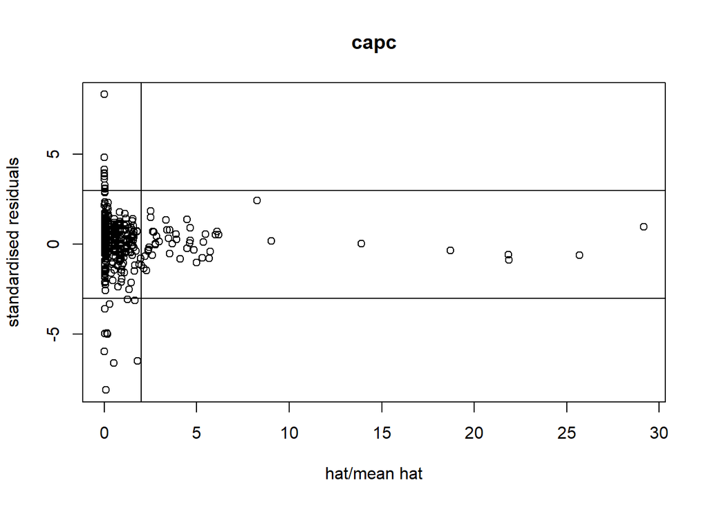

```r
rstn <- rstandard(ex.mv.capc)
hat <- hatvalues(ex.mv.capc) / mean(hatvalues(ex.mv.capc))
plot(hat, rstn$resid,
     xlab = "hat/mean hat",
     ylab = "standardised residuals",
     main = "capc")
abline(h = -3)
abline(h = 3)
abline(v = 2)
```

## Viechtbauer method

Estimate

```r
rstd.capc <- rstudent(ex.mv.capc, reestimate = FALSE, progbar = TRUE)
```

```r
x <- subset(rstd.capc, rstd.capc$resid > 1.96)
y <- subset(rstd.capc, rstd.capc$resid < -1.96)
length(x[["resid"]]) + length(y[["resid"]])
```

```
## [1] 41
```

```r
ex.mv.capc$k / 10
```

```
## [1] 48.8
```

```r
dfb.capc <- dfbetas.rma.mv(ex.mv.capc, reestimate = FALSE, progbar = TRUE)
```

```r
summary(dfb.capc)
```

```
##  factor.capc.1        factor.capc.2        factor.capc.3.6
##  Min.   :-2.889e-01   Min.   :-0.5472440   Min.   :-0.3897775
##  1st Qu.:-2.277e-03   1st Qu.:-0.0010686   1st Qu.:-0.0007289
##  Median :-1.050e-06   Median :-0.0000014   Median :-0.0000127
##  Mean   :-4.700e-04   Mean   :-0.0007478   Mean   :-0.0004391
##  3rd Qu.: 3.179e-03   3rd Qu.: 0.0010254   3rd Qu.: 0.0006024
##  Max.   : 2.074e-01   Max.   : 0.3100170   Max.   : 0.3864784
##  factor.capc.7.10     factor.capc.15.22    factor.capc.32.40
##  Min.   :-2.031e-01   Min.   :-0.5730503   Min.   :-2.993e-01
##  1st Qu.:-1.169e-05   1st Qu.:-0.0000025   1st Qu.:-1.287e-05
##  Median :-3.300e-07   Median :-0.0000001   Median :-3.500e-07
##  Mean   :-5.667e-04   Mean   : 0.0004273   Mean   :-6.001e-04
##  3rd Qu.: 3.880e-06   3rd Qu.: 0.0000008   3rd Qu.: 3.910e-06
##  Max.   : 2.351e-01   Max.   : 1.0151715   Max.   : 2.371e-01
##  factor.capc..40
##  Min.   :-0.8759209
##  1st Qu.:-0.0001085
##  Median :-0.0000040
##  Mean   :-0.0007158
##  3rd Qu.: 0.0000412
##  Max.   : 0.6554912
```

```r
subset(dfb.capc, dfb.capc$factor.capc.15.22 > 1) # 322
```

```
##     factor.capc.1 factor.capc.2 factor.capc.3.6 factor.capc.7.10
## 322 -0.0001152693 -9.910592e-05   -0.0008248961      -0.09926858
##     factor.capc.15.22 factor.capc.32.40 factor.capc..40
## 322          1.015172        -0.2705247     -0.02833617
```

```r
x$slab # none
```

```
##  [1]  26  30  31  34  35  36  37  38  95 103 108 113 114 115 116 199 258 383 392
## [20] 411
```

```r
ex[322, c("paper", "obs_ID", "capc")]
```

```
##            paper obs_ID  capc
## 322 Gendron_2007    422 15-22
```

- Observation 422 is influential, but not an outlier.
- Comparison with previous dataset that included density: Obs 422 is now influential.

# Months between C applications

```r
ex.mv.capm <- rma.mv(yi = yi,
                     V = vi,
                     random = ~ 1 | exp_ID / obs_ID,
                     data = ex,
                     mods = ~ factor(capm) - 1)
```

## Habeck method

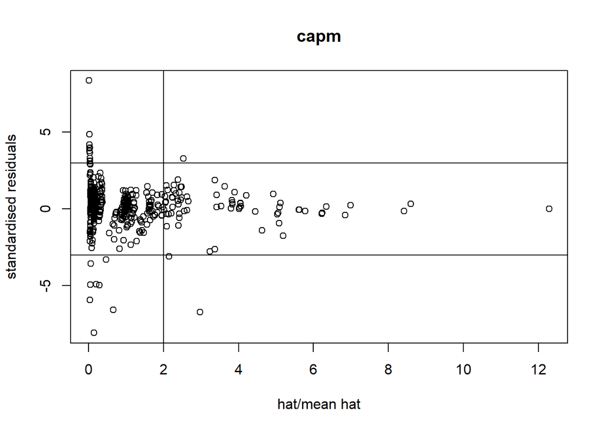

```r
rstn <- rstandard(ex.mv.capm)
hat <- hatvalues(ex.mv.capm) / mean(hatvalues(ex.mv.capm))
plot(hat, rstn$resid,
     xlab = "hat/mean hat",
     ylab = "standardised residuals",
     main = "capm")
abline(h = -3)
abline(h = 3)
abline(v = 2)
```

## Viechtbauer method

Estimate

```r
rstd.capm <- rstudent(ex.mv.capm, reestimate = FALSE, progbar = TRUE)
```

```r
x <- subset(rstd.capm, rstd.capm$resid > 1.96)
y <- subset(rstd.capm, rstd.capm$resid < -1.96)
length(x[["resid"]]) + length(y[["resid"]])
```

```
## [1] 42
```

```r
ex.mv.capm$k / 10
```

```
## [1] 48.8
```

```r
dfb.capm <- dfbetas.rma.mv(ex.mv.capm, reestimate = FALSE, progbar = TRUE)
```

```r
summary(dfb.capm)
```

```
##  factor.capm.1.application.total factor.capm..1       factor.capm.1.2
##  Min.   :-2.915e-01              Min.   :-0.6518308   Min.   :-0.3414308
##  1st Qu.:-3.225e-03              1st Qu.:-0.0000241   1st Qu.:-0.0004851
##  Median :-4.951e-05              Median :-0.0000010   Median :-0.0000159
##  Mean   :-5.522e-04              Mean   : 0.0004569   Mean   :-0.0012329
##  3rd Qu.: 3.777e-03              3rd Qu.: 0.0000298   3rd Qu.: 0.0004390
##  Max.   : 1.906e-01              Max.   : 0.3007479   Max.   : 0.3792655
##  factor.capm.2.4      factor.capm.4.11
##  Min.   :-0.4183225   Min.   :-2.884e-01
##  1st Qu.:-0.0011360   1st Qu.:-2.033e-04
##  Median :-0.0000763   Median :-1.068e-05
##  Mean   : 0.0006633   Mean   :-9.937e-04
##  3rd Qu.: 0.0011367   3rd Qu.: 1.011e-04
##  Max.   : 0.4001130   Max.   : 1.674e-01
```

- Observations 257, 457, and 601 are Habeck outliers.
- Comparison with previous dataset that included density: Obs 257, 457, and 601 are outliers.

# Months applying C

```r
ex.mv.capt <- rma.mv(yi = yi,
                     V = vi,
                     random = ~ 1 | exp_ID / obs_ID,
                     data = ex,
                     mods = ~ factor(capt) - 1)
```

## Habeck method

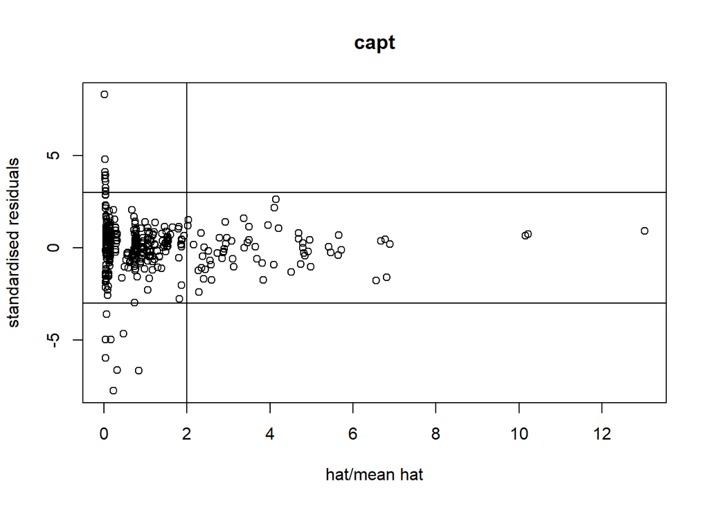

```r
rstn <- rstandard(ex.mv.capt)
hat <- hatvalues(ex.mv.capt) / mean(hatvalues(ex.mv.capt))
plot(hat, rstn$resid,
     xlab = "hat/mean hat",
     ylab = "standardised residuals",
     main = "capt")
abline(h = -3)
abline(h = 3)
abline(v = 2)
```

## Viechtbauer method

Estimate

```r
rstd.capt <- rstudent(ex.mv.capt, reestimate = FALSE, progbar = TRUE)
```

```r
x <- subset(rstd.capt, rstd.capt$resid > 1.96)
y <- subset(rstd.capt, rstd.capt$resid < -1.96)
length(x[["resid"]]) + length(y[["resid"]])
```

```
## [1] 37
```

```r
ex.mv.capt$k / 10
```

```
## [1] 48.8
```

```r
dfb.capt <- dfbetas.rma.mv(ex.mv.capt, reestimate = FALSE, progbar = TRUE)
```

```r
summary(dfb.capt)
```

```
##  factor.capt.1.application.total factor.capt.1.6      factor.capt.7.12
##  Min.   :-0.2616660              Min.   :-0.4272070   Min.   :-0.3885012
##  1st Qu.:-0.0041729              1st Qu.:-0.0002699   1st Qu.:-0.0007026
##  Median : 0.0000000              Median : 0.0000000   Median : 0.0000000
##  Mean   :-0.0006506              Mean   :-0.0007469   Mean   :-0.0008376
##  3rd Qu.: 0.0043801              3rd Qu.: 0.0003456   3rd Qu.: 0.0007187
##  Max.   : 0.1950520              Max.   : 0.1909129   Max.   : 0.4399808
##  factor.capt.13.24   factor.capt.25.36    factor.capt.37.48
##  Min.   :-0.403739   Min.   :-0.5433094   Min.   :-0.1236721
##  1st Qu.: 0.000000   1st Qu.: 0.0000000   1st Qu.: 0.0000000
##  Median : 0.000000   Median : 0.0000000   Median : 0.0000000
##  Mean   : 0.001084   Mean   : 0.0008843   Mean   :-0.0001969
##  3rd Qu.: 0.000000   3rd Qu.: 0.0000000   3rd Qu.: 0.0000000
##  Max.   : 0.689817   Max.   : 0.6256422   Max.   : 0.1510363
##  factor.capt..48
##  Min.   :-0.2949575
##  1st Qu.: 0.0000000
##  Median : 0.0000000
##  Mean   : 0.0006638
##  3rd Qu.: 0.0000000
##  Max.   : 0.5785551
```

- Comparison with previous dataset that included density: no differences.

# Annual/perennial

```r
ex.mv.panp <- rma.mv(yi = yi,
                     V = vi,
                     random = ~ 1 | exp_ID / obs_ID,
                     data = ex,
                     mods = ~ factor(plant_anper) - 1)
```

## Habeck method

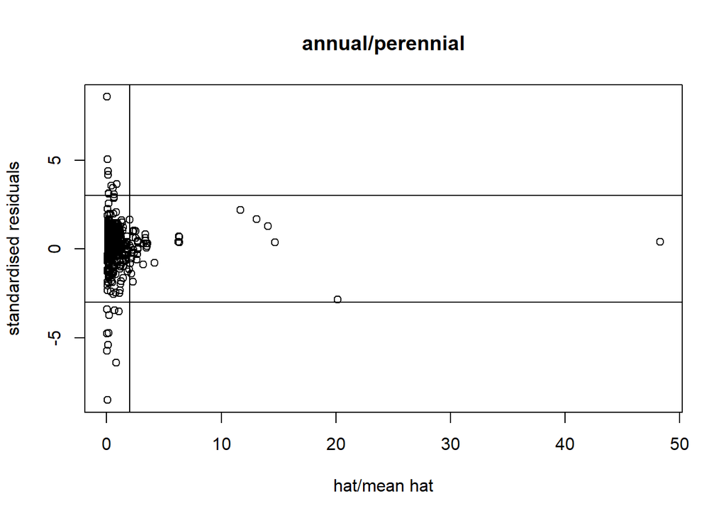

```r
rstn <- rstandard(ex.mv.panp)
hat <- hatvalues(ex.mv.panp) / mean(hatvalues(ex.mv.panp))
plot(hat, rstn$resid,
     xlab = "hat/mean hat",
     ylab = "standardised residuals",
     main = "annual/perennial")
abline(h = -3)
abline(h = 3)
abline(v = 2)
```

## Viechtbauer method

Estimate

```r
rstd.panp <- rstudent(ex.mv.panp, reestimate = FALSE, progbar = TRUE)
```

```r
x <- subset(rstd.panp, rstd.panp$resid > 1.96)
y <- subset(rstd.panp, rstd.panp$resid < -1.96)
length(x[["resid"]]) + length(y[["resid"]])
```

```
## [1] 39
```

```r
ex.mv.panp$k / 10
```

```
## [1] 48.8
```

```r
dfb.panp <- dfbetas.rma.mv(ex.mv.panp, reestimate = FALSE, progbar = TRUE)
```

```r
summary(dfb.panp)
```

```
##  factor.plant_anper.annual factor.plant_anper.biennial
##  Min.   :-0.269633         Min.   :-0.9126075
##  1st Qu.:-0.010308         1st Qu.:-0.0015073
##  Median :-0.001186         Median :-0.0000681
##  Mean   :-0.001154         Mean   :-0.0006914
##  3rd Qu.: 0.007755         3rd Qu.: 0.0015614
##  Max.   : 0.189762         Max.   : 0.4484960
##  factor.plant_anper.perennial factor.plant_anper.unknown
##  Min.   :-0.1978364           Min.   :-0.2535459
##  1st Qu.:-0.0088822           1st Qu.:-0.0023744
##  Median : 0.0002442           Median :-0.0002290
##  Mean   :-0.0010935           Mean   : 0.0009142
##  3rd Qu.: 0.0110532           3rd Qu.: 0.0025407
##  Max.   : 0.1556085           Max.   : 0.2403629
```

- Comparison with previous dataset that included density: no differences.

# Grass/forb/shrub

```r
ex.mv.pgfs <- rma.mv(yi = yi,
                     V = vi,
                     random = ~ 1 | exp_ID / obs_ID,
                     data = ex,
                     mods = ~ factor(plant_gfs) - 1)
```

## Habeck method

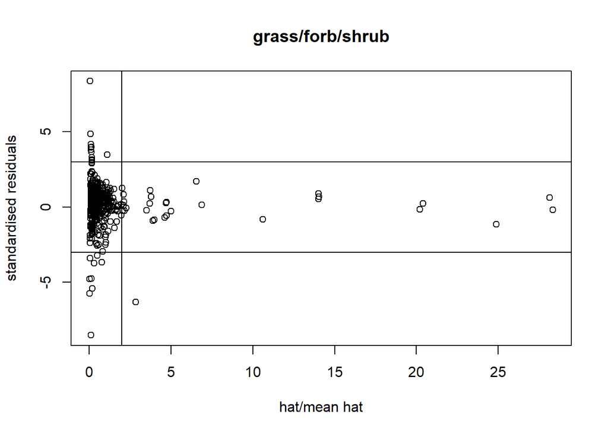

```r
rstn <- rstandard(ex.mv.pgfs)
hat <- hatvalues(ex.mv.pgfs) / mean(hatvalues(ex.mv.pgfs))
plot(hat, rstn$resid,
     xlab = "hat/mean hat",
     ylab = "standardised residuals",
     main = "grass/forb/shrub")
abline(h = -3)
abline(h = 3)
abline(v = 2)
```

```r
filter(ex, obs_ID == 257)[ , c("paper", "obs_ID", "plant_gfs")]
```

```
##        paper obs_ID plant_gfs
## 1 Brown_2017    257   unknown
```

```r
filter(ex, obs_ID == 258)[ , c("paper", "obs_ID", "plant_gfs")]
```

```
##        paper obs_ID plant_gfs
## 1 Brown_2017    258   unknown
```

## Viechtbauer method

Estimate

```r
rstd.pgfs <- rstudent(ex.mv.pgfs, reestimate = FALSE, progbar = TRUE)
```

```r
x <- subset(rstd.pgfs, rstd.pgfs$resid > 1.96)
y <- subset(rstd.pgfs, rstd.pgfs$resid < -1.96)
length(x[["resid"]]) + length(y[["resid"]])
```

```
## [1] 40
```

```r
ex.mv.pgfs$k / 10
```

```
## [1] 48.8
```

```r
dfb.pgfs <- dfbetas.rma.mv(ex.mv.pgfs, reestimate = FALSE, progbar = TRUE)
```

```r
summary(dfb.pgfs)
```

```
##  factor.plant_gfs.forb factor.plant_gfs.graminoid factor.plant_gfs.shrub
##  Min.   :-1.895e-01    Min.   :-0.1397560         Min.   :-0.4816750
##  1st Qu.:-1.018e-02    1st Qu.:-0.0067998         1st Qu.:-0.0008325
##  Median :-9.075e-04    Median : 0.0003114         Median :-0.0000787
##  Mean   :-3.523e-05    Mean   :-0.0007696         Mean   :-0.0001024
##  3rd Qu.: 8.285e-03    3rd Qu.: 0.0069506         3rd Qu.: 0.0007330
##  Max.   : 2.165e-01    Max.   : 0.1244753         Max.   : 0.6642838
##  factor.plant_gfs.unknown
##  Min.   :-0.4571741
##  1st Qu.:-0.0007636
##  Median : 0.0000477
##  Mean   : 0.0001607
##  3rd Qu.: 0.0008460
##  Max.   : 0.3252039
```

- Observations 257 and 258 are Habeck outliers (points are overlapping on plot).
- Comparison with previous datset that included density: Obs 257 and 258 are outliers.

# Annual/perennial and grass/forb/shrub

```r
ex.mv.papgfs <- rma.mv(yi = yi,
                     V = vi,
                     random = ~ 1 | exp_ID / obs_ID,
                     data = ex,
                     mods = ~ factor(plant_apgfs) - 1)
```

## Habeck method

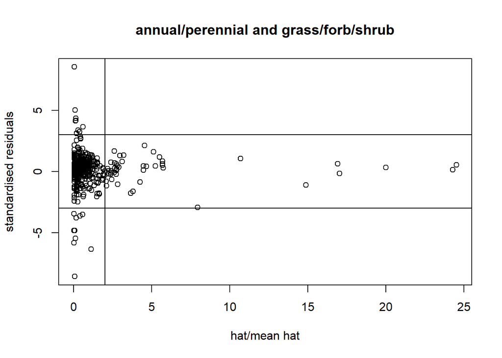

```r
rstn <- rstandard(ex.mv.papgfs)
hat <- hatvalues(ex.mv.papgfs) / mean(hatvalues(ex.mv.papgfs))
plot(hat, rstn$resid,
     xlab = "hat/mean hat",
     ylab = "standardised residuals",
     main = "annual/perennial and grass/forb/shrub")
abline(h = -3)
abline(h = 3)
abline(v = 2)
```

## Viechtbauer method

Estimate

```r
rstd.papgfs <- rstudent(ex.mv.papgfs, reestimate = FALSE, progbar = TRUE)
```

```r
x <- subset(rstd.papgfs, rstd.papgfs$resid > 1.96)
y <- subset(rstd.papgfs, rstd.papgfs$resid < -1.96)
length(x[["resid"]]) + length(y[["resid"]])
```

```
## [1] 35
```

```r
ex.mv.papgfs$k / 10
```

```
## [1] 48.8
```

```r
dfb.papgfs <- dfbetas.rma.mv(ex.mv.papgfs, reestimate = FALSE, progbar = TRUE)
```

```r
summary(dfb.papgfs)
```

```
##  factor.plant_apgfs.annual.forb factor.plant_apgfs.annual.graminoid
##  Min.   :-0.3042624             Min.   :-0.169102
##  1st Qu.:-0.0132791             1st Qu.:-0.008462
##  Median :-0.0007022             Median : 0.000000
##  Mean   :-0.0006889             Mean   :-0.000893
##  3rd Qu.: 0.0078738             3rd Qu.: 0.007739
##  Max.   : 0.2731378             Max.   : 0.176940
##  factor.plant_apgfs.biennial.forb factor.plant_apgfs.perennial.forb
##  Min.   :-0.8579022               Min.   :-0.3792765
##  1st Qu.:-0.0016348               1st Qu.:-0.0071892
##  Median :-0.0000016               Median : 0.0002442
##  Mean   :-0.0005949               Mean   :-0.0007827
##  3rd Qu.: 0.0015651               3rd Qu.: 0.0098641
##  Max.   : 0.4402501               Max.   : 0.1550705
##  factor.plant_apgfs.perennial.graminoid factor.plant_apgfs.perennial.shrub
##  Min.   :-0.2248251                     Min.   :-2.525e-01
##  1st Qu.:-0.0039634                     1st Qu.:-5.279e-04
##  Median :-0.0002112                     Median :-3.482e-05
##  Mean   :-0.0007523                     Mean   :-5.445e-04
##  3rd Qu.: 0.0045186                     3rd Qu.: 5.526e-04
##  Max.   : 0.2782054                     Max.   : 2.549e-01
##  factor.plant_apgfs.unknown.forb factor.plant_apgfs.unknown.graminoid
##  Min.   :-2.075e-01              Min.   :-0.4013932
##  1st Qu.:-2.204e-03              1st Qu.:-0.0016699
##  Median :-5.076e-05              Median :-0.0000771
##  Mean   : 8.652e-04              Mean   : 0.0000909
##  3rd Qu.: 2.328e-03              3rd Qu.: 0.0012917
##  Max.   : 2.631e-01              Max.   : 0.6797720
##  factor.plant_apgfs.unknown.shrub factor.plant_apgfs.unknown.unknown
##  Min.   :-0.7555619               Min.   :-0.4582059
##  1st Qu.:-0.0006287               1st Qu.:-0.0010580
##  Median :-0.0000292               Median : 0.0000070
##  Mean   : 0.0003445               Mean   : 0.0002545
##  3rd Qu.: 0.0006316               3rd Qu.: 0.0010867
##  Max.   : 0.7858545               Max.   : 0.3405765
```

- Comparison with previous datset that included density: no differences.

# Plot size

```r
ex.mv.plotc <- rma.mv(yi = yi,
                       V = vi,
                       random = ~ 1 | exp_ID / obs_ID,
                       data = ex,
                       mods = ~ factor(plotc) - 1)
```

## Habeck method

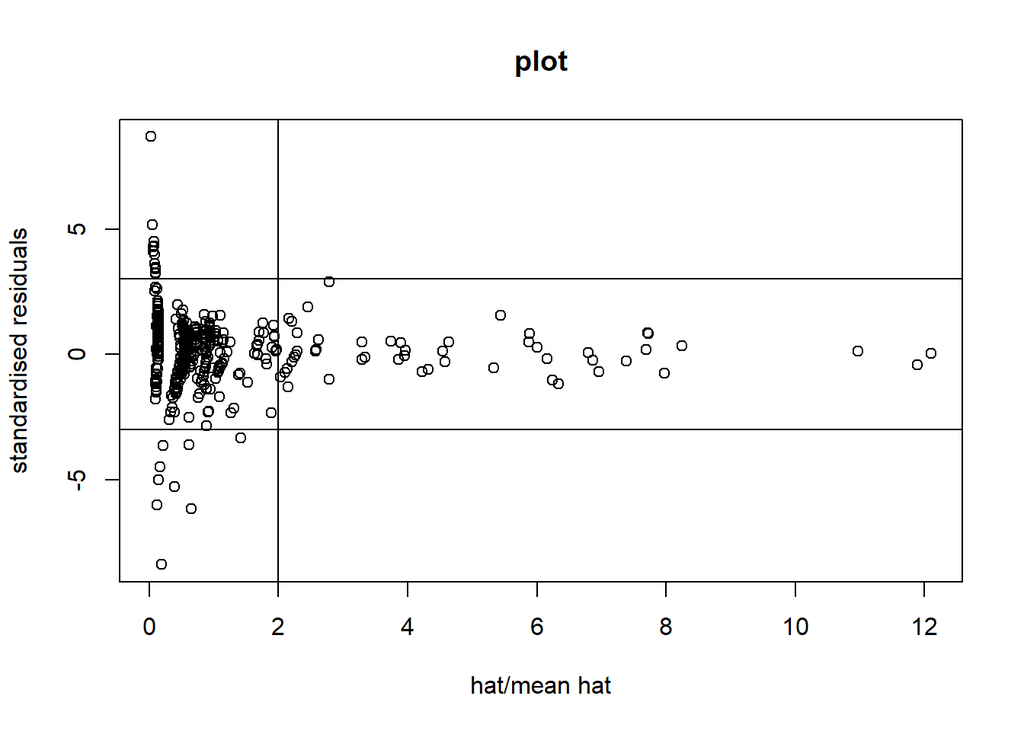

```r
rstn <- rstandard(ex.mv.plotc)
hat <- hatvalues(ex.mv.plotc) / mean(hatvalues(ex.mv.plotc))
plot(hat, rstn$resid,
     xlab = "hat/mean hat",
     ylab = "standardised residuals",
     main = "plot")
abline(h = -3)
abline(h = 3)
abline(v = 2)
```

## Viechtbauer method

Estimate

```r
rstd.plotc <- rstudent(ex.mv.plotc, reestimate = FALSE, progbar = TRUE)
```

```r
x <- subset(rstd.plotc, rstd.plotc$resid > 1.96)
y <- subset(rstd.plotc, rstd.plotc$resid < -1.96)
length(x[["resid"]]) + length(y[["resid"]])
```

```
## [1] 42
```

```r
ex.mv.plotc$k / 10
```

```
## [1] 48.2
```

```r
dfb.plotc <- dfbetas.rma.mv(ex.mv.plotc, reestimate = FALSE, progbar = TRUE)
```

```r
summary(dfb.plotc)
```

```
##  factor.plotc..1      factor.plotc.1       factor.plotc.1.3.3.75
##  Min.   :-0.3092990   Min.   :-0.3414712   Min.   :-0.4021356
##  1st Qu.: 0.0000000   1st Qu.: 0.0000000   1st Qu.: 0.0000000
##  Median : 0.0000000   Median : 0.0000000   Median : 0.0000000
##  Mean   :-0.0005299   Mean   : 0.0001401   Mean   : 0.0001522
##  3rd Qu.: 0.0000000   3rd Qu.: 0.0000000   3rd Qu.: 0.0000000
##  Max.   : 0.1414592   Max.   : 0.4969643   Max.   : 0.4047428
##  factor.plotc.4       factor.plotc.6.9    factor.plotc.12
##  Min.   :-0.3978989   Min.   :-0.216901   Min.   :-3.537e-02
##  1st Qu.: 0.0000000   1st Qu.: 0.000000   1st Qu.: 0.000e+00
##  Median : 0.0000000   Median : 0.000000   Median : 0.000e+00
##  Mean   :-0.0007364   Mean   : 0.001206   Mean   : 7.060e-06
##  3rd Qu.: 0.0000000   3rd Qu.: 0.000000   3rd Qu.: 0.000e+00
##  Max.   : 0.1840933   Max.   : 0.624039   Max.   : 4.194e-02
##  factor.plotc.12.5.16 factor.plotc.25      factor.plotc.28.50
##  Min.   :-0.488879    Min.   :-3.533e-02   Min.   :-2.652e-01
##  1st Qu.: 0.000000    1st Qu.: 0.000e+00   1st Qu.: 0.000e+00
##  Median : 0.000000    Median : 0.000e+00   Median : 0.000e+00
##  Mean   :-0.002264    Mean   : 3.728e-05   Mean   : 3.008e-05
##  3rd Qu.: 0.000000    3rd Qu.: 0.000e+00   3rd Qu.: 0.000e+00
##  Max.   : 0.025898    Max.   : 4.830e-02   Max.   : 2.432e-01
##  factor.plotc.75      factor.plotc..100
##  Min.   :-0.2953547   Min.   :-0.200945
##  1st Qu.: 0.0000000   1st Qu.: 0.000000
##  Median : 0.0000000   Median : 0.000000
##  Mean   :-0.0003594   Mean   : 0.000235
##  3rd Qu.: 0.0000000   3rd Qu.: 0.000000
##  Max.   : 0.2145420   Max.   : 0.469892
```

- Comparison with previous dataset that included density: this is a new moderator.

# Seeding of native

```r
ex.mv.seedn <- rma.mv(yi = yi,
                      V = vi,
                      random = ~ 1 | exp_ID / obs_ID,
                      data = ex,
                      mods = ~ factor(seedn) - 1)
```

## Habeck method

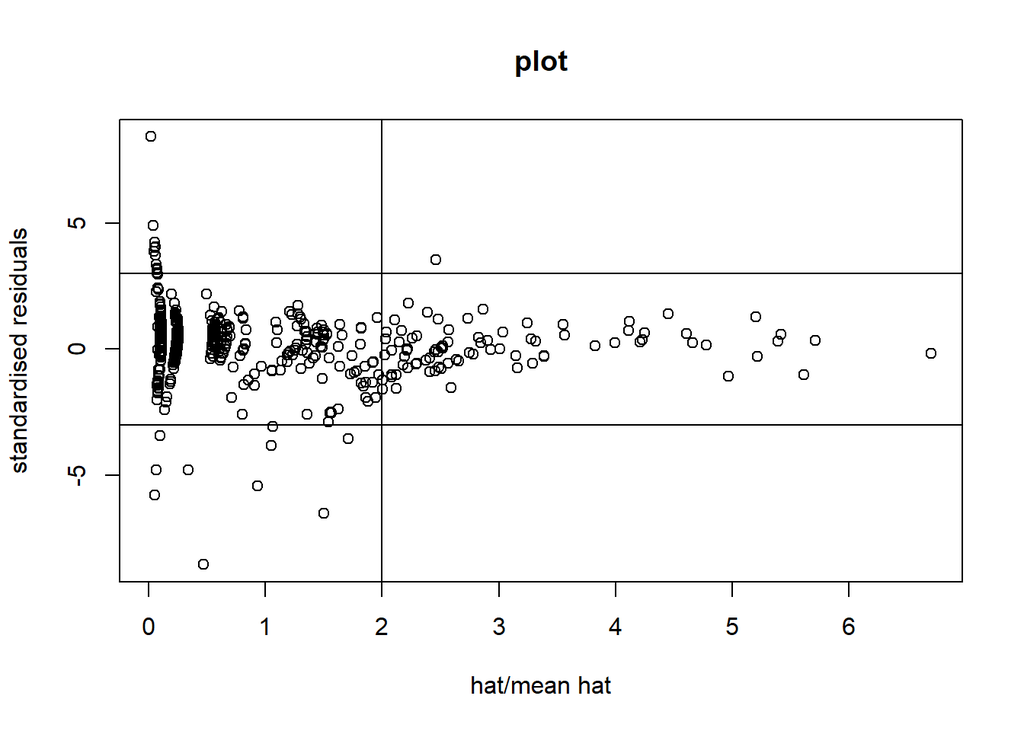

```r
rstn <- rstandard(ex.mv.seedn)
hat <- hatvalues(ex.mv.seedn) / mean(hatvalues(ex.mv.seedn))
plot(hat, rstn$resid,
     xlab = "hat/mean hat",
     ylab = "standardised residuals",
     main = "plot")
abline(h = -3)
abline(h = 3)
abline(v = 2)
```

```r
filter(ex, obs_ID == 457)[ , c("paper", "obs_ID", "seedn")]
```

```
##          paper obs_ID         seedn
## 1 Hoelzle_2010    457 native seeded
```

## Viechtbauer method

Estimate

```r
rstd.seedn <- rstudent(ex.mv.seedn, reestimate = FALSE, progbar = TRUE)
```

```r
x <- subset(rstd.seedn, rstd.seedn$resid > 1.96)
y <- subset(rstd.seedn, rstd.seedn$resid < -1.96)
length(x[["resid"]]) + length(y[["resid"]])
```

```
## [1] 40
```

```r
ex.mv.seedn$k / 10
```

```
## [1] 48.8
```

```r
dfb.seedn <- dfbetas.rma.mv(ex.mv.seedn, reestimate = FALSE, progbar = TRUE)
```

```r
summary(dfb.seedn)
```

```
##  factor.seedn.native.not.seeded factor.seedn.native.seeded
##  Min.   :-0.1973066             Min.   :-2.395e-01
##  1st Qu.:-0.0034408             1st Qu.:-2.732e-03
##  Median :-0.0001355             Median :-1.063e-05
##  Mean   :-0.0002757             Mean   :-4.158e-04
##  3rd Qu.: 0.0025658             3rd Qu.: 3.740e-03
##  Max.   : 0.2579624             Max.   : 2.153e-01
```

- Observation 457 is a Habeck outlier.

# Model selection 14

```r
ex.ms14 <- ex[!apply(ex[ , c("region", "dlc", "C_type", "cratc", "capt", "plant_apgfs", "plotc")], 1, anyNA), ]

ex.mv.ms14 <- rma.mv(yi = yi,
                    V = vi,
                    random = ~ 1 | exp_ID / obs_ID,
                    data = ex.ms14,
                    mods = ~ 1 + dlc + plotc + region + plant_apgfs)
```

## Habeck method

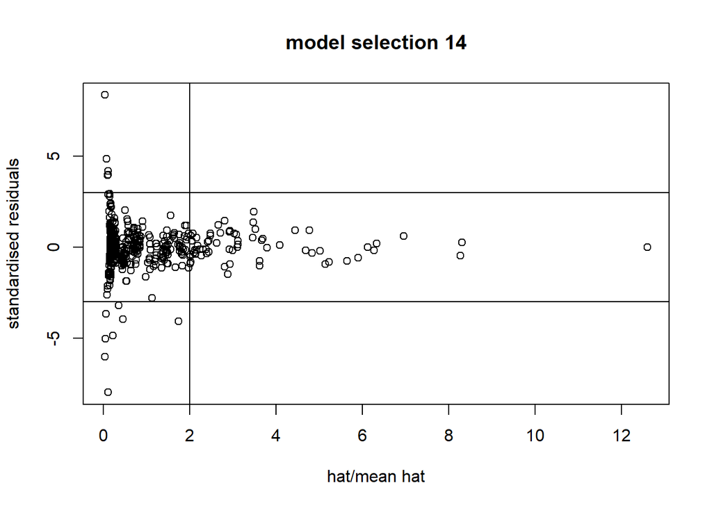

```r
rstn <- rstandard(ex.mv.ms14)
hat <- hatvalues(ex.mv.ms14) / mean(hatvalues(ex.mv.ms14))
plot(hat, rstn$resid,
     xlab = "hat/mean hat",
     ylab = "standardised residuals",
     main = "model selection 14")
abline(h = -3)
abline(h = 3)
abline(v = 2)
```

## Viechtbauer method

Estimate

```r
rstd.ms14 <- rstudent(ex.mv.ms14, reestimate = FALSE, progbar = TRUE)
```

```r
x <- subset(rstd.ms14, rstd.ms14$resid > 1.96)
y <- subset(rstd.ms14, rstd.ms14$resid < -1.96)
length(x[["resid"]]) + length(y[["resid"]])
```

```
## [1] 30
```

```r
ex.mv.ms14$k / 10
```

```
## [1] 46.6
```

```r
dfb.ms14 <- dfbetas.rma.mv(ex.mv.ms14, reestimate = FALSE, progbar = TRUE)
```

```r
summary(dfb.ms14)
```

```
##     intrcpt                dlc2               dlc3.3.5
##  Min.   :-0.1851250   Min.   :-0.3726948   Min.   :-0.396517
##  1st Qu.:-0.0017528   1st Qu.:-0.0031866   1st Qu.:-0.005193
##  Median : 0.0000000   Median : 0.0000000   Median : 0.000000
##  Mean   :-0.0000493   Mean   : 0.0000987   Mean   : 0.000354
##  3rd Qu.: 0.0015924   3rd Qu.: 0.0035075   3rd Qu.: 0.006555
##  Max.   : 0.1862492   Max.   : 0.3704453   Max.   : 0.419331
##  NA's   :1            NA's   :1            NA's   :1
##      dlc4.6              dlc7.12              dlc13.18
##  Min.   :-0.2591543   Min.   :-0.4620655   Min.   :-0.3869497
##  1st Qu.:-0.0058250   1st Qu.:-0.0009270   1st Qu.:-0.0075275
##  Median : 0.0000000   Median : 0.0000000   Median : 0.0000000
##  Mean   : 0.0004383   Mean   :-0.0002306   Mean   : 0.0001977
##  3rd Qu.: 0.0059505   3rd Qu.: 0.0015987   3rd Qu.: 0.0068640
##  Max.   : 0.2581952   Max.   : 0.7083799   Max.   : 0.3933219
##  NA's   :1            NA's   :1            NA's   :1
##     dlc19.24             dlc36.49             dlc.100
##  Min.   :-0.4838395   Min.   :-0.3911534   Min.   :-0.865119
##  1st Qu.:-0.0042372   1st Qu.:-0.0017302   1st Qu.:-0.002069
##  Median : 0.0000000   Median : 0.0000000   Median : 0.000000
##  Mean   :-0.0009331   Mean   : 0.0003993   Mean   :-0.001347
##  3rd Qu.: 0.0041161   3rd Qu.: 0.0019836   3rd Qu.: 0.002732
##  Max.   : 0.7530430   Max.   : 0.4100579   Max.   : 0.829194
##  NA's   :1            NA's   :1            NA's   :1
##      plotc1           plotc1.3.3.75            plotc4
##  Min.   :-0.5316858   Min.   :-0.6298818   Min.   :-0.5299546
##  1st Qu.:-0.0025678   1st Qu.:-0.0021339   1st Qu.:-0.0047220
##  Median : 0.0000000   Median : 0.0000000   Median : 0.0000000
##  Mean   :-0.0004322   Mean   :-0.0009718   Mean   :-0.0008848
##  3rd Qu.: 0.0023322   3rd Qu.: 0.0018464   3rd Qu.: 0.0034145
##  Max.   : 0.4833756   Max.   : 0.5872419   Max.   : 0.6487394
##  NA's   :1            NA's   :1            NA's   :1
##     plotc6.9             plotc12            plotc12.5.16
##  Min.   :-0.5608351   Min.   :-0.7689843   Min.   :-0.587286
##  1st Qu.:-0.0035755   1st Qu.:-0.0076900   1st Qu.:-0.003707
##  Median : 0.0000000   Median :-0.0000440   Median : 0.000000
##  Mean   :-0.0005716   Mean   :-0.0009395   Mean   :-0.001130
##  3rd Qu.: 0.0050347   3rd Qu.: 0.0062714   3rd Qu.: 0.003126
##  Max.   : 0.6524715   Max.   : 0.4782282   Max.   : 0.517559
##  NA's   :1            NA's   :1            NA's   :1
```

[output cut: 57 more lines]

```
##  Min.   :-0.2852892      Min.   :-0.3650551           Min.   :-0.8397631
##  1st Qu.:-0.0063676      1st Qu.:-0.0051345           1st Qu.:-0.0031540
##  Median : 0.0000000      Median : 0.0000000           Median : 0.0000000
##  Mean   : 0.0008145      Mean   : 0.0007663           Mean   : 0.0002969
##  3rd Qu.: 0.0116576      3rd Qu.: 0.0070691           3rd Qu.: 0.0041074
##  Max.   : 0.3090727      Max.   : 0.7159310           Max.   : 1.1083201
##  NA's   :1               NA's   :1                    NA's   :1
##  plant_apgfsunknown.unknown
##  Min.   :-0.4734668
##  1st Qu.:-0.0051408
##  Median : 0.0000000
##  Mean   :-0.0005319
##  3rd Qu.: 0.0065925
##  Max.   : 0.2577007
##  NA's   :1
```